# Introduction

Cancer remains one of the leading causes of death worldwide, responsible for approximately 10 million deaths annually (Gou X, 2025). Alarmingly, 70% of cancer deaths are accounted by low and mid income countries. This is primarily because of limited access to screening, diagnosis, treatment, and palliative care (Oghenekaro, 2025). Cancer can be seen as not only a medical challenge, but also a socioeconomic one. To make healthcare outcome more equitable, novel innovations in AI can be utilized for early detections in improving survival outcomes for patients.

DL learning, a subset of machine learning, is the revolutionary machine learning architecture spearheading the innovation in early cancer detection for improved prognosis. Utilizing convolutional neural networks, machine learning algorithms learn end-to-end complex features in medical images that are relevant to an image classification or an object detection problem. Such advancement increases societal health outcomes by enabling accelerated and accurate medical image interpretation and analysis. This is especially helpful in low and mid income countries where there is inadequate screening infrastructure.

In this project we will be working with the Bangladesh Brain Cancer MRI dataset. The dataset is a comprehensive collection of brain MRI images meticulously sourced from various hospitals in Bangladesh on three brain cancer types: meningioma, glioma, and pituitary tumor. Utilizing this data we will train a neural network classifier and answer the following research questions:

- What level of performance can be reached with an end-to-end neural network utilizing a moderate sample size?
- Which neural network architecture is most performant and why?

### References

Gou X, F. A. (2025). Imaging genomics of cancer: a bibliometric analysis and review. Cancer Imaging.

Oghenekaro, E. A. (2025). Deep Learning-Based Computer Vision Models for Early Cancer Detection Using Multimodal Medical Imaging and Radiogenomic Integration Frameworks. International Journal of Computer Applications Technology and Research .

```python
import pandas as pd
import numpy as np
import posixpath
import matplotlib.pyplot as plt
import seaborn as sns
from keras.utils import image_dataset_from_directory
import tensorflow as tf
import keras
import os
import numpy
from sklearn import metrics
from PIL import Image
```

```python
from google.colab import drive
drive.mount('/content/drive')
```

```python
# Attempting to control randomness for increased reproducibility and debugging
seed = 777

# Setting 'PYTHONHASHSEED' environment variable to a fixed value
os.environ['PYTHONHASHSEED']=str(seed)

# Set python built-in psuedo-random generator at a fixed value
import random
random.seed(seed)

# Set numpy pseudo-random generator at fixed value
import numpy as np
np.random.seed(seed)

# Setting tensorflow psuedo-random generator at a fixed value
import tensorflow as tf
tf.random.set_seed(seed)
```

# Filtering out corrupted images

```python
#  Created a function to detect corrupt images
def is_image_corrupted(image_path):
    try:
        img = Image.open(image_path) # Opening image
        img.verify() # verifing its integerity
        return False
    except (IOError, SyntaxError) as e: # raising exception if integrity check fails
        print(f"Image {image_path} is corrupted: {e}")
    except Exception as e:
           print(f"An unexpected error occured: {e}")
           return True

# Adapted from https://woteq.com/detecting-corrupted-images-in-python-using-pil/#google_vignette

# Creating a object to store skipped instances
num_skipped = 0
num_checked = 0
# Creating loop that detects corrupt files
loc_base = r'/content/drive/MyDrive/Spatial Model Project/Brain_Cancer'
for folder_name in ('brain_glioma', 'brain_menin', 'brain_tumor'):
    folder_path = os.path.join(loc_base, folder_name) # Extracting the file directories
    for fname in os.listdir(folder_path): # Looping through each full file path of the images
        num_checked+= 1 # Counting the number of files checked
        fpath = os.path.join(folder_path, fname) # Obtaining the file directory
        is_corrupted = is_image_corrupted(fpath)
        if is_corrupted == True:
            num_skipped += + 1

# Displaying the numer of files corrupted
print(f'Total files checked: {num_checked}, Count of corrupt images: {num_skipped}')

# Adapted from https://keras.io/examples/vision/image_classification_from_scratch/
```

```
Total files checked: 6012, Count of corrupt images: 0
```

No corrupt files

# Loading data

```python
# Creating directory path
dir = r'/content/drive/MyDrive/Spatial Model Project/Brain_Cancer'

# Unpacking data into two datasets
train_ds, val_ds = image_dataset_from_directory(
    dir,
    label_mode="int",
    validation_split=0.30,
    subset='both',
    batch_size=None, # .split_dataset does not work with nested arrays
    seed=333,
    image_size= (512,512)) # Resizes all images to this specified size
```

```
Found 6012 files belonging to 3 classes.
Using 4209 files for training.
Using 1803 files for validation.
```

```python
# Creating a test set to create a train (70%), validation (15%), and test set (15%)
val_ds, test_ds = tf.keras.utils.split_dataset(val_ds, left_size=0.50)
```

During model fitting, callbacks are utilized to monitor model performance on a validation set and stop model fitting when overfitting is detected. As the model is being optimized on the validation set, performing model evaluation with the same validation dataset can provide a biased performance evaluation. To mitigate this risk, a third dataset, a test set, is created to test the final model on new unseen data for a fair assessment of model performance.

```python
# Listing class names
train_ds.class_names
```

```
['brain_glioma', 'brain_menin', 'brain_tumor']
```

```python
# Batching the datasets
train_ds = train_ds.batch(batch_size=32)
val_ds = val_ds.batch(batch_size=32)
test_ds = test_ds.batch(batch_size=32)
```

```python
# Count total samples
num_rows = sum(1 for row in train_ds.unbatch())

# Get image shape
for images, labels in train_ds.take(1):
    image_shape = images.shape[1:]  # (height, width, channels)

print(f"Rows (images): {num_rows}")
print(f"Image shape: {image_shape}")
```

```
Rows (images): 4209
Image shape: (512, 512, 3)
```

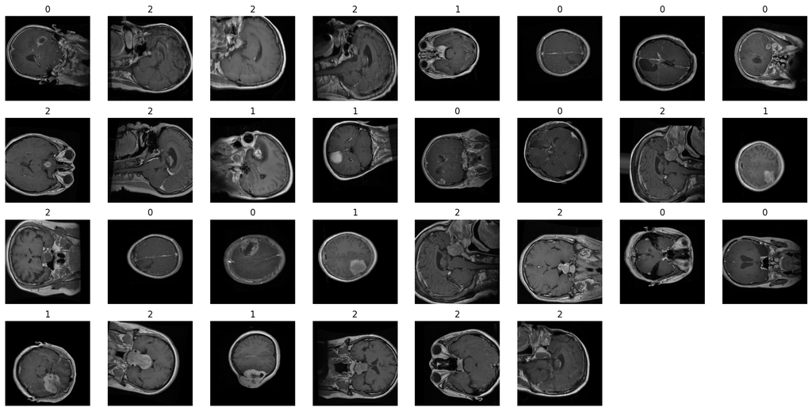

```python
# Defining a function to view data
plt.figure(figsize=(20, 20))
for images, labels in train_ds.take(1): # Takes the first batch of images
    for i in range(30):
        ax = plt.subplot(8, 8, i + 1) # Creating the subplot figure
        plt.imshow(np.array(images[i]).astype("uint8"), cmap= 'gray_r') # Plotting the individual image
        plt.title(int(labels[i])) # Plotting the label
        plt.axis("off")
```

Data appears to have loading in correctly

# Creating baseline modeling - Dense model

For baseline modeling, two dense neural networks will be developed. One network will contain data augmentation layers consisting of small random translations and random scaling of the medical images. The second dense network will not contain any data augmentation. The purpose of this is twofold. First, these two models will enable the performance evaluation of the augmentation layers. Computer vision research for medical imaging recommends data augmentation to increase data diversity, increase spatial feature invariance, and reduce overfitting. Second, it will allow an evaluation of the effectiveness of recommended data augmentation techniques for MRI image classification. For classification tasks using MRI images literature suggests utilizing translation, scaling, and rotation. Translation is a data augmentation technique that involves shifting the image from its fixed frame. Shifting the image ever so slightly will mitigate positional bias, forcing the model to learn geographically invariant features (Goceri, 2023). Scaling or augmentation via zooming will teach the model to be invariant to the scale of cancer lesions and focus on learning generalizable patterns regardless of size (Goceri, 2023). Rotation can help with generating features for detecting lesions at different positions. An issue with the technique is that rotating MRI images creates unrealistic new data that does not conform to the standardized MRI Imaging format. For this reason, it was decided not to proceed with this data augmentation technique.

```python
# Creating the dense model without augmentation
model_wo_aug = keras.Sequential([
keras.Input(shape=(512,512,3)),

# Scaling the rgb channel to be of range [0,1]
keras.layers.Rescaling(scale=1./255),

# Passing input to hidden layers
keras.layers.Dense(50, activation='relu'),
keras.layers.Dense(50, activation='relu'),
keras.layers.Flatten(),
keras.layers.Dropout(0.2),
keras.layers.Dense(3, activation='softmax')
])
```

```python
# Creating the dense model without augmentation
model_w_aug = keras.Sequential([
keras.Input(shape=(512,512,3)),

# Adding Augmentation layers
keras.layers.RandomTranslation(height_factor=(-0.05, 0.05), width_factor=(-0.05, 0.05), fill_mode='constant', fill_value=0.0, seed=seed, data_format='channels_last'), # shifts the images randomly by 5% and fills in '0' values where appropriate due to the shift
keras.layers.RandomZoom(height_factor=(-0.05, 0.05), width_factor=(-0.05, 0.05), fill_mode='constant', fill_value=0.0, seed=seed), # Randomly scales images  by 5% and fills in '0' values where appropriate due to the random scaling

# Scaling the rgb channel to be of range [0,1]
keras.layers.Rescaling(scale=1./255),

# passing input to hidden layers
keras.layers.Dense(50, activation='relu'),
keras.layers.Dense(50, activation='relu'),
keras.layers.Flatten(),
keras.layers.Dropout(0.2),
keras.layers.Dense(3, activation='softmax')
])
```

```python
# Reviewing model summary
model_wo_aug.summary()
```

```
Model: "sequential"
```

```
┏━━━━━━━━━━━━━━━━━━━━━━━━━━━━━━━━━┳━━━━━━━━━━━━━━━━━━━━━━━━┳━━━━━━━━━━━━━━━┓
┃ Layer (type)                    ┃ Output Shape           ┃       Param # ┃
┡━━━━━━━━━━━━━━━━━━━━━━━━━━━━━━━━━╇━━━━━━━━━━━━━━━━━━━━━━━━╇━━━━━━━━━━━━━━━┩
│ rescaling (Rescaling)           │ (None, 512, 512, 3)    │             0 │
├─────────────────────────────────┼────────────────────────┼───────────────┤
│ dense (Dense)                   │ (None, 512, 512, 50)   │           200 │
├─────────────────────────────────┼────────────────────────┼───────────────┤
│ dense_1 (Dense)                 │ (None, 512, 512, 50)   │         2,550 │
├─────────────────────────────────┼────────────────────────┼───────────────┤
│ flatten (Flatten)               │ (None, 13107200)       │             0 │
├─────────────────────────────────┼────────────────────────┼───────────────┤
│ dropout (Dropout)               │ (None, 13107200)       │             0 │
├─────────────────────────────────┼────────────────────────┼───────────────┤
│ dense_2 (Dense)                 │ (None, 3)              │    39,321,603 │
└─────────────────────────────────┴────────────────────────┴───────────────┘
```

```
 Total params: 39,324,353 (150.01 MB)
```

```
 Trainable params: 39,324,353 (150.01 MB)
```

```
 Non-trainable params: 0 (0.00 B)
```

```python
# Reviewing model summary
model_w_aug.summary()
```

```
Model: "sequential_1"
```

```
┏━━━━━━━━━━━━━━━━━━━━━━━━━━━━━━━━━┳━━━━━━━━━━━━━━━━━━━━━━━━┳━━━━━━━━━━━━━━━┓
┃ Layer (type)                    ┃ Output Shape           ┃       Param # ┃
┡━━━━━━━━━━━━━━━━━━━━━━━━━━━━━━━━━╇━━━━━━━━━━━━━━━━━━━━━━━━╇━━━━━━━━━━━━━━━┩
│ random_translation              │ (None, 512, 512, 3)    │             0 │
│ (RandomTranslation)             │                        │               │
├─────────────────────────────────┼────────────────────────┼───────────────┤
│ random_zoom (RandomZoom)        │ (None, 512, 512, 3)    │             0 │
├─────────────────────────────────┼────────────────────────┼───────────────┤
│ rescaling_1 (Rescaling)         │ (None, 512, 512, 3)    │             0 │
├─────────────────────────────────┼────────────────────────┼───────────────┤
│ dense_3 (Dense)                 │ (None, 512, 512, 50)   │           200 │
├─────────────────────────────────┼────────────────────────┼───────────────┤
│ dense_4 (Dense)                 │ (None, 512, 512, 50)   │         2,550 │
├─────────────────────────────────┼────────────────────────┼───────────────┤
│ flatten_1 (Flatten)             │ (None, 13107200)       │             0 │
├─────────────────────────────────┼────────────────────────┼───────────────┤
│ dropout_1 (Dropout)             │ (None, 13107200)       │             0 │
├─────────────────────────────────┼────────────────────────┼───────────────┤
│ dense_5 (Dense)                 │ (None, 3)              │    39,321,603 │
└─────────────────────────────────┴────────────────────────┴───────────────┘
```

```
 Total params: 39,324,353 (150.01 MB)
```

```
 Trainable params: 39,324,353 (150.01 MB)
```

```
 Non-trainable params: 0 (0.00 B)
```

```python
# Compiling the models
model_wo_aug.compile(loss='sparse_categorical_crossentropy', metrics=['accuracy'])
model_w_aug.compile(loss='sparse_categorical_crossentropy', metrics=['accuracy'])
```

Instantiating callbacks

```python
from keras.callbacks import EarlyStopping, TensorBoard
import datetime

# Early stopping callback to prevent overfitting
early_stopping = EarlyStopping(
    monitor='val_loss',  # Monitor validation loss
    patience=5,          # Stop after 5 epochs with no improvement
    min_delta=0.001,     # Minimum change to qualify as improvement
    verbose=2,           # Display messages when callback takes action
    restore_best_weights=True # Restore weights from the best epoch
)

# Comprehensive dashboard on model fitting statistics
logdir = os.path.join("logs", datetime.datetime.now().strftime("%Y%m%d-%H%M%S"))

performance_eval = TensorBoard(
    logdir,
    histogram_freq=1
)
```

```python
# Fitting the without augmentation model
history_wo_aug = model_wo_aug.fit(train_ds, batch_size=128, epochs=50, validation_data=val_ds, callbacks=[early_stopping, performance_eval]) # Directly passing a tf.data.Dataset object
```

```
132/132 ━━━━━━━━━━━━━━━━━━━━ 46s 263ms/step - accuracy: 0.5292 - loss: 32.7077 - val_accuracy: 0.5588 - val_loss: 0.9779
132/132 ━━━━━━━━━━━━━━━━━━━━ 11s 79ms/step - accuracy: 0.7502 - loss: 0.6262 - val_accuracy: 0.7439 - val_loss: 0.6085
132/132 ━━━━━━━━━━━━━━━━━━━━ 10s 79ms/step - accuracy: 0.8367 - loss: 0.4374 - val_accuracy: 0.7018 - val_loss: 0.8995
132/132 ━━━━━━━━━━━━━━━━━━━━ 10s 79ms/step - accuracy: 0.8863 - loss: 0.3196 - val_accuracy: 0.7262 - val_loss: 0.8021
132/132 ━━━━━━━━━━━━━━━━━━━━ 10s 79ms/step - accuracy: 0.9352 - loss: 0.1829 - val_accuracy: 0.6907 - val_loss: 0.9852
132/132 ━━━━━━━━━━━━━━━━━━━━ 10s 79ms/step - accuracy: 0.9677 - loss: 0.0996 - val_accuracy: 0.7339 - val_loss: 1.0335
132/132 ━━━━━━━━━━━━━━━━━━━━ 10s 79ms/step - accuracy: 0.9804 - loss: 0.0883 - val_accuracy: 0.7228 - val_loss: 1.2867
Epoch 7: early stopping
Restoring model weights from the end of the best epoch: 2.
```

```python
# Loading the tensorboard extension
%load_ext tensorboard
```

```python
%tensorboard --logdir logs
```

```python
# Fitting the model with data augmentation
history_w_aug = model_w_aug.fit(train_ds, batch_size=128, epochs=50, validation_data=val_ds, callbacks=[early_stopping, performance_eval]) # Directly passing a tf.data.Dataset object
```

```
132/132 ━━━━━━━━━━━━━━━━━━━━ 22s 148ms/step - accuracy: 0.5137 - loss: 24.8495 - val_accuracy: 0.6940 - val_loss: 0.6804
132/132 ━━━━━━━━━━━━━━━━━━━━ 19s 144ms/step - accuracy: 0.7008 - loss: 0.7140 - val_accuracy: 0.7417 - val_loss: 0.6141
132/132 ━━━━━━━━━━━━━━━━━━━━ 19s 144ms/step - accuracy: 0.7285 - loss: 0.6772 - val_accuracy: 0.7849 - val_loss: 0.5670
132/132 ━━━━━━━━━━━━━━━━━━━━ 19s 143ms/step - accuracy: 0.7555 - loss: 0.6126 - val_accuracy: 0.7483 - val_loss: 0.5988
132/132 ━━━━━━━━━━━━━━━━━━━━ 19s 143ms/step - accuracy: 0.7536 - loss: 0.6134 - val_accuracy: 0.7650 - val_loss: 0.5860
132/132 ━━━━━━━━━━━━━━━━━━━━ 19s 143ms/step - accuracy: 0.7596 - loss: 0.6184 - val_accuracy: 0.7439 - val_loss: 0.6078
132/132 ━━━━━━━━━━━━━━━━━━━━ 19s 144ms/step - accuracy: 0.7717 - loss: 0.5609 - val_accuracy: 0.7949 - val_loss: 0.5556
132/132 ━━━━━━━━━━━━━━━━━━━━ 19s 146ms/step - accuracy: 0.7665 - loss: 0.5700 - val_accuracy: 0.7805 - val_loss: 0.5380
132/132 ━━━━━━━━━━━━━━━━━━━━ 19s 143ms/step - accuracy: 0.7812 - loss: 0.5638 - val_accuracy: 0.7262 - val_loss: 0.6461
132/132 ━━━━━━━━━━━━━━━━━━━━ 19s 144ms/step - accuracy: 0.7748 - loss: 0.5602 - val_accuracy: 0.7761 - val_loss: 0.5257
132/132 ━━━━━━━━━━━━━━━━━━━━ 19s 143ms/step - accuracy: 0.7851 - loss: 0.5527 - val_accuracy: 0.7439 - val_loss: 0.6288
132/132 ━━━━━━━━━━━━━━━━━━━━ 19s 144ms/step - accuracy: 0.7942 - loss: 0.5285 - val_accuracy: 0.6286 - val_loss: 1.3513
132/132 ━━━━━━━━━━━━━━━━━━━━ 19s 143ms/step - accuracy: 0.7690 - loss: 0.5698 - val_accuracy: 0.7506 - val_loss: 0.6128
132/132 ━━━━━━━━━━━━━━━━━━━━ 19s 144ms/step - accuracy: 0.7872 - loss: 0.5261 - val_accuracy: 0.7805 - val_loss: 0.5577
132/132 ━━━━━━━━━━━━━━━━━━━━ 19s 143ms/step - accuracy: 0.7638 - loss: 0.5677 - val_accuracy: 0.7572 - val_loss: 0.5890
Epoch 15: early stopping
Restoring model weights from the end of the best epoch: 10.
```

```python
%tensorboard --logdir logs
```

```
Reusing TensorBoard on port 6006 (pid 34020), started 0:04:49 ago. (Use '!kill 34020' to kill it.)
```

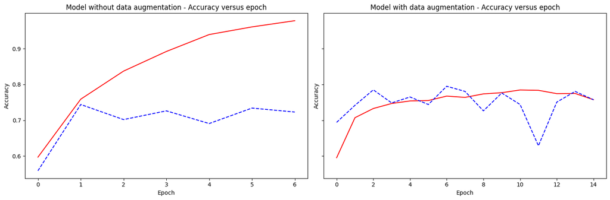

```python
# Plotting the accuracy versus epoch statistics
fig = plt.subplots(ncols=2, figsize=(15, 5),sharey=True)

plt.subplot(1,2,1)
plt.plot(history_wo_aug.epoch, history_wo_aug.history['accuracy'], color='red', label='Training')
plt.plot(history_wo_aug.epoch, history_wo_aug.history['val_accuracy'], color='blue', label='Validation',linestyle="--")
plt.title('Model without data augmentation - Accuracy versus epoch')
plt.xlabel('Epoch')
plt.ylabel('Accuracy')

plt.subplot(1,2,2)
plt.plot(history_w_aug.epoch, history_w_aug.history['accuracy'], color='red', label='Training')
plt.plot(history_w_aug.epoch, history_w_aug.history['val_accuracy'], color='blue', label='Validation',linestyle="--")
plt.title('Model with data augmentation - Accuracy versus epoch')
plt.xlabel('Epoch')
plt.ylabel('Accuracy')

plt.tight_layout()
```

Reviewing the accuracy versus epoch for both models reveals insights on data augmentation’s impact on model fitting. The dashed blue line represents the validation accuracy while the red line represents the training accuracy.

The lefthand visualization shows that an absence of data augmentation increases model overfitting. After the first epoch, training and validation accuracy are approximately in the 75% - 78% range. As the model continues to reduce its errors via backpropagation, the disparity in training and validation accuracy increases in each subsequent epoch. After the first epoch, the validation accuracy converges around the mid 70% while training accuracy increases at a decreasing rate. When the callback terminates the model fitting, the model has effectively memorized the training dataset and not enough generalizable features to increase the test set accuracy performance. Moving to the righthand-side illustrates an ideal training process.

The righthand visualization illustrates that data augmentation increases model performance and mitigates overfitting. A notable remark is that validation accuracy is found to consistently meet or exceed training accuracy in multiple epochs. This is an interesting observation given that the model trained without data augmentation never exceeded training accuracy. This suggests that the data augmentation layers succeeded in forcing the model to learn generalizable patterns for model classification. Another notable remark is that the training accuracy and validation accuracy converged at a similar accuracy metric. This illustrates that as the model was updating its weights via backpropagation, all new patterns learned in the training dataset were directly useful for predicting unseen data.

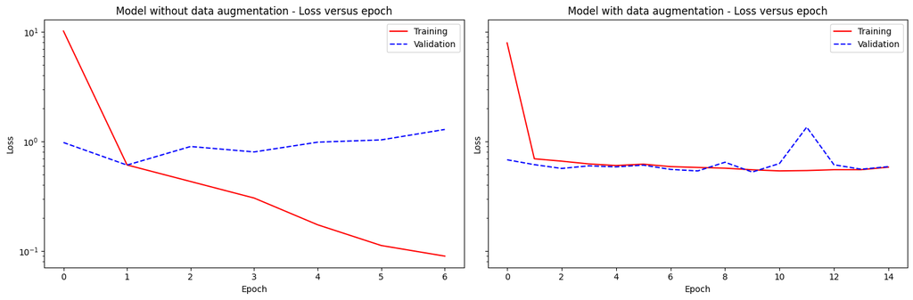

```python
# Plotting loss versus epoch statistics
fig = plt.subplots(ncols=2, figsize=(15, 5),sharey=True)

plt.subplot(1,2,1)
plt.semilogy(history_wo_aug.epoch, history_wo_aug.history['loss'], color='red', label='Training')
plt.semilogy(history_wo_aug.epoch, history_wo_aug.history['val_loss'], color='blue', label='Validation',linestyle="--")
plt.title('Model without data augmentation - Loss versus epoch')
plt.xlabel('Epoch')
plt.ylabel('Loss')
plt.legend()

plt.subplot(1,2,2)
plt.semilogy(history_w_aug.epoch, history_w_aug.history['loss'], color='red', label='Training')
plt.semilogy(history_w_aug.epoch, history_w_aug.history['val_loss'], color='blue', label='Validation',linestyle="--")
plt.title('Model with data augmentation - Loss versus epoch')
plt.xlabel('Epoch')
plt.ylabel('Loss')
plt.legend()

plt.tight_layout()
```

The loss versus epoch visualization confirms the insights gathered in the accuracy versus epoch analysis. On the lefthand side is the loss versus epoch statistics for the model without data augmentation. The sparce cross entropy loss function is found to decrease in each subsequent epoch for the training dataset. Although, after the first epoch, the validation loss continues to increase showing signs of overfitting. The model is learning patterns in the data, along with noise which is why it performs so poorly with unseen data. The right-hand visualization shows that the validation loss and the training loss consistently follow each other, converging after the third epoch. Therefore, empirically, it is shown that data augmentation does increase model performance and mitigates overfitting. Each alternative neural network architecture in this study will include the augmentation layers.

```python
# Extracting the predicted outputs (probabilities)
pred_model_wo_aug = model_wo_aug.predict(test_ds)
pred_model_w_aug = model_w_aug.predict(test_ds)
```

```
29/29 ━━━━━━━━━━━━━━━━━━━━ 9s 259ms/step
29/29 ━━━━━━━━━━━━━━━━━━━━ 2s 61ms/step
```

```python
# Extracting the predicted labels
pred_model_wo_aug_labels = numpy.argmax(pred_model_wo_aug, axis=1)
pred_model_w_aug_labels = numpy.argmax(pred_model_w_aug, axis=1)
```

```python
import tensorflow_datasets as tfds

# Extracting the true labels from the test tensor
test_ds_numpy = tfds.as_numpy(test_ds)

# Creating a loop to extract the label for each image and place it in a list
true_labels = []
for img, label in test_ds_numpy:
    true_labels.append(label)
```

```python
# Merging the set of arrays together to make a 1-D array of labels
true_labels = np.concatenate(true_labels, axis=0)
```

```python
# Reviewing extraction
true_labels
```

```
array([2, 2, 1, 2, 1, 2, 2, 0, 2, 0, 2, 2, 0, 2, 1, 1, 1, 0, 2, 1, 1, 1,
       2, 1, 1, 2, 1, 2, 1, 0, 0, 0, 1, 2, 1, 0, 1, 1, 1, 0, 2, 0, 0, 2,
       2, 0, 1, 1, 2, 1, 2, 0, 0, 2, 0, 1, 0, 0, 2, 1, 2, 1, 1, 0, 0, 1,
       0, 1, 0, 0, 1, 0, 0, 0, 0, 1, 2, 2, 2, 0, 1, 2, 1, 0, 1, 1, 1, 1,
       2, 0, 1, 1, 1, 0, 2, 0, 0, 1, 2, 0, 1, 0, 2, 0, 1, 0, 0, 2, 2, 0,
       1, 0, 0, 2, 0, 0, 2, 0, 1, 0, 2, 2, 2, 1, 0, 0, 1, 1, 1, 0, 1, 2,
       1, 1, 0, 0, 2, 2, 2, 1, 1, 2, 0, 0, 1, 2, 1, 0, 1, 1, 1, 0, 1, 0,
       0, 2, 2, 1, 0, 1, 1, 0, 0, 0, 0, 2, 1, 0, 2, 2, 0, 0, 0, 0, 1, 2,
       0, 2, 0, 0, 0, 1, 0, 1, 2, 2, 0, 1, 2, 0, 1, 2, 1, 0, 1, 2, 1, 0,
       1, 1, 2, 2, 0, 2, 0, 0, 2, 0, 2, 2, 1, 2, 1, 0, 1, 0, 1, 1, 2, 0,
       1, 0, 0, 0, 1, 0, 2, 0, 2, 1, 1, 0, 1, 1, 2, 1, 0, 1, 1, 2, 2, 2,
       2, 1, 1, 1, 1, 0, 2, 0, 1, 0, 0, 2, 1, 1, 1, 1, 1, 2, 2, 0, 1, 2,
       2, 2, 2, 0, 1, 2, 0, 0, 0, 1, 0, 2, 1, 2, 0, 1, 0, 1, 0, 2, 1, 1,
       0, 0, 2, 1, 2, 0, 0, 2, 1, 0, 1, 1, 0, 2, 2, 2, 2, 0, 0, 1, 2, 0,
       2, 2, 2, 0, 1, 0, 0, 0, 1, 1, 2, 1, 1, 0, 2, 0, 0, 1, 2, 0, 1, 1,
```

[output cut: 27 more lines]

```python
# Viewing balance accuracy
print(
    f'''
    model_wo_aug Balanced Accuracy: {metrics.balanced_accuracy_score(true_labels, pred_model_wo_aug_labels)}
    model_w_aug Balanced Accuracy: {metrics.balanced_accuracy_score(true_labels, pred_model_w_aug_labels)}
    ''')
```

```
    model_wo_aug Balanced Accuracy: 0.754715467692101
    model_w_aug Balanced Accuracy: 0.7810360021613304
```

In this context, balanced accuracy is not strictly necessary as the class labels are balanced well. Balanced accuracy is utilized as it is the average of the class recalls, a statistic that is informative in describing how well the classifier detects all class instances. It is revealed that the model with data augmentation has an average class recall rate of 78% compared to 75% of the alternative model. Suggesting once again that data augmentation improves predictive power through robust feature learning. Improvements to this baseline accuracy will be attempted via convolutional neural network architectures in subsequent modeling sections.

```python
# Creating a AUC curve
def ROC_displayer(model_1, model_2, true_labels, pred_test_labels_1, pred_test_labels_2, title_1,title_2):

  from sklearn.preprocessing import LabelBinarizer
  from sklearn.metrics import RocCurveDisplay

  lb = LabelBinarizer()
  lb.fit(true_labels)
  binarized_labels_true = lb.transform(true_labels)
  binarized_labels_128 = lb.transform(pred_test_labels_1)
  binarized_labels_256 = lb.transform(pred_test_labels_2)


  # Extracting class names
  class_names = ['brain_glioma', 'brain_menin', 'brain_tumor']

  fig, ax = plt.subplots(nrows=1, ncols=2, figsize=(20, 20))

  ax = ax.flatten()

  # Model 1
  RocCurveDisplay.from_predictions(
    binarized_labels_true[:,0],
    binarized_labels_128[:,0],
    name=f'{model_1}:{class_names[0]} vs the rest',
    ax=ax[0],
    despine=True
  )

  RocCurveDisplay.from_predictions(
    binarized_labels_true[:,1],
    binarized_labels_128[:,1],
    name=f'{model_1}:{class_names[1]} vs the rest',
    despine=True,
    ax=ax[0]
  )

  RocCurveDisplay.from_predictions(
    binarized_labels_true[:,2],
    binarized_labels_128[:,2],
    name=f'{model_1}:{class_names[2]} vs the rest',
    despine=True,
    plot_chance_level = True,
    ax=ax[0]
  )

  # Model 2
  RocCurveDisplay.from_predictions(
    binarized_labels_true[:,0],
    binarized_labels_256[:,0],
    name=f'{model_2}:{class_names[0]} vs the rest',
    ax=ax[1],
    despine=True
  )

  RocCurveDisplay.from_predictions(
    binarized_labels_true[:,1],
    binarized_labels_256[:,1],
    name=f'{model_2}:{class_names[1]} vs the rest',
    despine=True,
    ax=ax[1]
  )

  RocCurveDisplay.from_predictions(
    binarized_labels_true[:,2],
    binarized_labels_256[:,2],
    name=f'{model_2}:{class_names[2]} vs the rest',
    despine=True,
    plot_chance_level = True,
    ax=ax[1]
  )

  # Setting title
  ax[0].set_title(title_1)
  ax[1].set_title(title_2)

  # Display graphs
  plt.show()
```

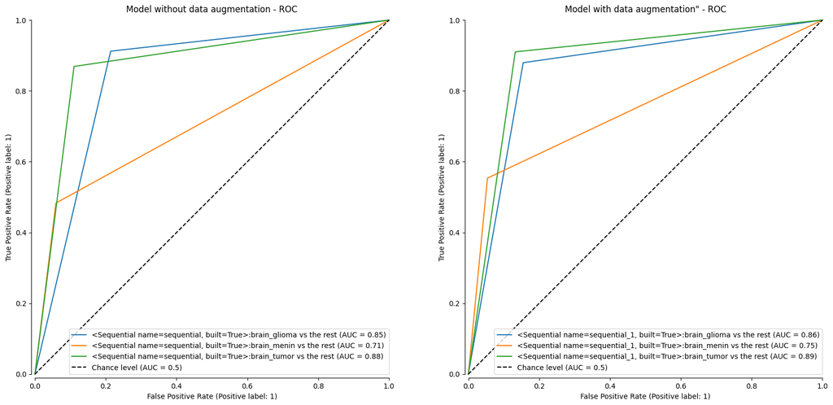

```python
# Displaying model ROC results
ROC_displayer(model_wo_aug, model_w_aug,true_labels, pred_model_wo_aug_labels, pred_model_w_aug_labels, 'Model without data augmentation - ROC','Model with data augmentation" - ROC' )
```

The ROC graph is a great visual representation of the quality of a classifier. The ROC graph is originally intended for a binary classifier and has been adapted here for multi-class classification via the one-versus-all method. The ROC plots the true positive rate over the false positive rate and depicts the model’s performance across different classification thresholds. The area under the curve, or the AUC, is the metric of interest with high values indicating strong discriminatory ability. Models with high AUC values will hug the top left of the ROC graph. Coveying that a small reduction in the classification threshold will capture most of the true positives. The dashed line in the center is the chance AUC, meaning that any AUC value higher than 0.50 improves upon a random chance classifier. If a model has an AUC statistic less than a random chance classifier, its predictions should be inverted.

The ROC curve on the left reveals disparate performance across the different target classes. The “brain_glioma” class $(AUC=0.85)$ reaches the highest true positive rate of all the classes, but introduces more false positives to accomplish so. The “brain_tumor” class provides the best balance between true positives and false positives, receiving an AUC of $0.88$. Lastly, the “brain_menin” class struggles to achieve a similar true positive rate performance to the other classes in the model. It has a low true positive rate at earlier thresholds, a lower AUC statistic $(AUC=0.71)$, and introduces meaningful erroneous classifications as the classification threshold decreases. Introducing data augmentation appears to alleviate these disparate performance issues.

The ROC graph on the right depicts the one-versus- all class performances of the model with data augmentation. A notable remark is that the AUC statistic has improved for all classes, with “brain_menin” $(AUC=0.75)$ receiving a meaningful increase from its baseline levels $(AUC=0.71)$. We find that across all classification thresholds, more true positives for “brain_menin” are captured, and fewer erroneous classifications are made. Notable improvements are seen with the “brain_glioma” $(AUC=0.86)$ and “brain_tumor” $(AUC=0.89)$, the most apparent is the proximity of the ROC curves. Both classes now have very similar performances, with “brain_glioma” improving on its precision and “brain_tumor” improving on its recall. Therefore, it is clear that translation and scaling layers provide meaningful improvement to model performance.

```python
from sklearn.metrics import classification_report
target_names = ['brain_glioma', 'brain_menin', 'brain_tumor']
print('Model WITHOUT data augmentation')
print(classification_report(true_labels, pred_model_wo_aug_labels, target_names=target_names))
print("---------------------------------------")
print('Model WITH augmentation')
print(classification_report(true_labels, pred_model_w_aug_labels, target_names=target_names))
```

```
Model WITHOUT data augmentation
              precision    recall  f1-score   support

brain_glioma       0.69      0.91      0.78       307
 brain_menin       0.82      0.48      0.61       327
 brain_tumor       0.77      0.87      0.82       267

    accuracy                           0.74       901
   macro avg       0.76      0.75      0.74       901
weighted avg       0.76      0.74      0.73       901

---------------------------------------
Model WITH augmentation
              precision    recall  f1-score   support

brain_glioma       0.75      0.88      0.81       307
 brain_menin       0.85      0.55      0.67       327
 brain_tumor       0.74      0.91      0.82       267

    accuracy                           0.77       901
   macro avg       0.78      0.78      0.77       901
weighted avg       0.78      0.77      0.76       901
```

# Creating a convolutional model

In this section, we will create a convolutional neural network to improve upon the baseline model's performance. A convolutional neural network is a neural network architecture specialized for processing data of a grid-like topology. The network makes use of the mathematical operation of convolution: $s(t)$ = $(x*w)(t)$ = $\sum_{a=-\infty}^{\infty} x(a)*w(t-a)$ (Goodfellow, Bengio, & Courville, 2016). This formula describes a function that uses the average of several $t$ measurements to obtain the output value $s(t)$. The $x$ function can be thought of as the input, the $w$ function as a kernel or a weighter of the output of $x$, while the output of $s(t)$ is a feature map. This is a simple representation of a convolution function, where in reality the input of an image is multidimensional and defined as the following convolutional function: $S(i,j) = (K*I)(i,j)$ = $\sum_{m} \sum_{n} I(i-m,j-n)*K(m,n)$ (Goodfellow, Bengio, & Courville, 2016). In this formulation, the feature map $S(i,j)$ is being produced by sliding a kernel $(K(m,n))$ over the input image at $I(i-m,j-n)$ and weighting the output of $I$ by $K$. This is done iteratively for all valid values of an image to produce a feature map.

The implication of this mathematical formulation and the motivation for using this in a neural network is that it provides sparse interactions and parameter sharing. Sparse interactions limit the number of connections each input unit has to an output unit, reducing memory requirements and improving statistical efficiency. Parameter sharing means instead of learning a complete, unique set of parameters for every pixel in an image, a set of parameters is learned that is applied at all positions in an image. This significantly reduces the storage requirements and reduces the number of parameters that need to be learned by the model (Goodfellow, Bengio, & Courville, 2016). In the context of classifying cancer medical imaging, convolutional networks facilitate a drastic reduction in the parameters to be learned. This allows for deeper and more complex neural networks to develop generalizable features for classification.

### References

Goodfellow, I., Bengio, Y., & Courville, A. (2016). Deep Learning. MIT Press.

```python
# Creating convolutional model
model_convo = keras.Sequential(
    [
        # Input layer
        keras.Input(shape=(512,512,3)),

        # Rescaling
        keras.layers.Rescaling(1./255),

        # Adding Augmentation layers
        keras.layers.RandomTranslation(height_factor=(-0.05, 0.05), width_factor=(-0.05, 0.05), fill_mode='constant', fill_value=0.0, seed=seed, data_format='channels_last'),
        keras.layers.RandomZoom(height_factor=(-0.05, 0.05), width_factor=(-0.05, 0.05), fill_mode='constant', fill_value=0.0, seed=seed),

        # Applying hidden layers to input data
        keras.layers.Conv2D(32, kernel_size=(3, 3), activation="relu"),
        keras.layers.MaxPooling2D(pool_size=(2, 2)),
        keras.layers.Conv2D(64, kernel_size=(3, 3), activation="relu"),
        keras.layers.MaxPooling2D(pool_size=(2, 2)),
        keras.layers.Dense(20, activation='relu'),
        keras.layers.Flatten(),
        keras.layers.Dropout(0.5),
        keras.layers.Dense(3, activation="softmax"),
    ]
)
```

```python
# Printing model summary
model_convo.summary()
```

```
Model: "sequential_2"
```

```
┏━━━━━━━━━━━━━━━━━━━━━━━━━━━━━━━━━┳━━━━━━━━━━━━━━━━━━━━━━━━┳━━━━━━━━━━━━━━━┓
┃ Layer (type)                    ┃ Output Shape           ┃       Param # ┃
┡━━━━━━━━━━━━━━━━━━━━━━━━━━━━━━━━━╇━━━━━━━━━━━━━━━━━━━━━━━━╇━━━━━━━━━━━━━━━┩
│ rescaling_2 (Rescaling)         │ (None, 512, 512, 3)    │             0 │
├─────────────────────────────────┼────────────────────────┼───────────────┤
│ random_translation_1            │ (None, 512, 512, 3)    │             0 │
│ (RandomTranslation)             │                        │               │
├─────────────────────────────────┼────────────────────────┼───────────────┤
│ random_zoom_1 (RandomZoom)      │ (None, 512, 512, 3)    │             0 │
├─────────────────────────────────┼────────────────────────┼───────────────┤
│ conv2d (Conv2D)                 │ (None, 510, 510, 32)   │           896 │
├─────────────────────────────────┼────────────────────────┼───────────────┤
│ max_pooling2d (MaxPooling2D)    │ (None, 255, 255, 32)   │             0 │
├─────────────────────────────────┼────────────────────────┼───────────────┤
│ conv2d_1 (Conv2D)               │ (None, 253, 253, 64)   │        18,496 │
├─────────────────────────────────┼────────────────────────┼───────────────┤
│ max_pooling2d_1 (MaxPooling2D)  │ (None, 126, 126, 64)   │             0 │
├─────────────────────────────────┼────────────────────────┼───────────────┤
│ dense_6 (Dense)                 │ (None, 126, 126, 20)   │         1,300 │
├─────────────────────────────────┼────────────────────────┼───────────────┤
│ flatten_2 (Flatten)             │ (None, 317520)         │             0 │
├─────────────────────────────────┼────────────────────────┼───────────────┤
│ dropout_2 (Dropout)             │ (None, 317520)         │             0 │
├─────────────────────────────────┼────────────────────────┼───────────────┤
│ dense_7 (Dense)                 │ (None, 3)              │       952,563 │
└─────────────────────────────────┴────────────────────────┴───────────────┘
```

```
 Total params: 973,255 (3.71 MB)
```

```
 Trainable params: 973,255 (3.71 MB)
```

```
 Non-trainable params: 0 (0.00 B)
```

```python
# Compiling model
model_convo.compile(loss='sparse_categorical_crossentropy', metrics=['accuracy'])
```

```python
# Fitting the model
history_convo = model_convo.fit(train_ds, batch_size=128, epochs=50, validation_data=val_ds, callbacks=[early_stopping, performance_eval])
```

```
132/132 ━━━━━━━━━━━━━━━━━━━━ 15s 80ms/step - accuracy: 0.5537 - loss: 1.1073 - val_accuracy: 0.6242 - val_loss: 0.8274
132/132 ━━━━━━━━━━━━━━━━━━━━ 9s 67ms/step - accuracy: 0.6688 - loss: 0.7326 - val_accuracy: 0.7317 - val_loss: 0.6160
132/132 ━━━━━━━━━━━━━━━━━━━━ 9s 67ms/step - accuracy: 0.7054 - loss: 0.6706 - val_accuracy: 0.7738 - val_loss: 0.5556
132/132 ━━━━━━━━━━━━━━━━━━━━ 9s 67ms/step - accuracy: 0.7369 - loss: 0.6182 - val_accuracy: 0.7506 - val_loss: 0.6089
132/132 ━━━━━━━━━━━━━━━━━━━━ 9s 67ms/step - accuracy: 0.7472 - loss: 0.5831 - val_accuracy: 0.8271 - val_loss: 0.4764
132/132 ━━━━━━━━━━━━━━━━━━━━ 9s 67ms/step - accuracy: 0.7715 - loss: 0.5596 - val_accuracy: 0.8204 - val_loss: 0.4831
132/132 ━━━━━━━━━━━━━━━━━━━━ 9s 66ms/step - accuracy: 0.7884 - loss: 0.5103 - val_accuracy: 0.7550 - val_loss: 0.5529
132/132 ━━━━━━━━━━━━━━━━━━━━ 9s 67ms/step - accuracy: 0.7798 - loss: 0.5220 - val_accuracy: 0.7727 - val_loss: 0.5376
132/132 ━━━━━━━━━━━━━━━━━━━━ 9s 67ms/step - accuracy: 0.7992 - loss: 0.4998 - val_accuracy: 0.7749 - val_loss: 0.5213
132/132 ━━━━━━━━━━━━━━━━━━━━ 9s 67ms/step - accuracy: 0.8124 - loss: 0.4575 - val_accuracy: 0.6918 - val_loss: 0.7054
Epoch 10: early stopping
Restoring model weights from the end of the best epoch: 5.
```

```python
# Extracting the predicted outputs (probabilities)
pred_test = model_convo.predict(test_ds)
```

```
29/29 ━━━━━━━━━━━━━━━━━━━━ 1s 40ms/step
```

```python
# Viewing output
pred_test
```

```
array([[0.32382295, 0.12374339, 0.55243367],
       [0.01271417, 0.21306041, 0.77422535],
       [0.01139108, 0.7617768 , 0.22683212],
       ...,
       [0.97710127, 0.02090725, 0.00199148],
       [0.8345892 , 0.15729253, 0.00811823],
       [0.00284316, 0.02918898, 0.96796787]], dtype=float32)
```

```python
# Extracting the predicted labels
pred_test_labels = numpy.argmax(pred_test, axis=1)
```

```python
from sklearn import metrics

# Viewing balance accruacy
print(metrics.balanced_accuracy_score(true_labels, pred_test_labels))
```

```
0.8013801965783812
```

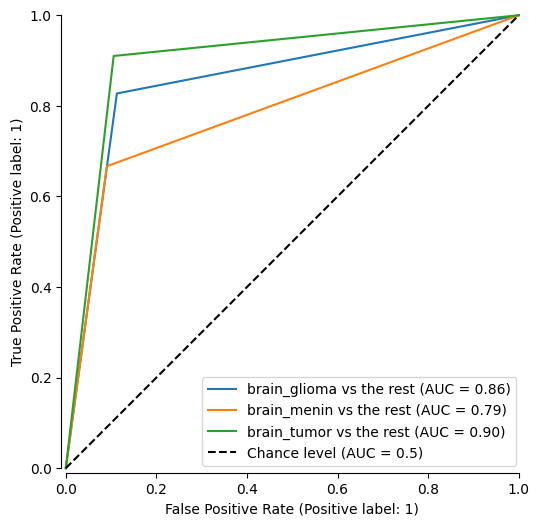

```python
# Creating a AUC curve
from sklearn.preprocessing import LabelBinarizer
from sklearn.metrics import RocCurveDisplay
lb = LabelBinarizer()
lb.fit(true_labels)
binarized_labels_true = lb.transform(true_labels)
binarized_labels = lb.transform(pred_test_labels)


# Extracting class names
class_names = ['brain_glioma', 'brain_menin', 'brain_tumor']

fig, ax = plt.subplots(figsize=(6, 6))

RocCurveDisplay.from_predictions(
  binarized_labels_true[:,0],
  binarized_labels[:,0],
  name=f'{class_names[0]} vs the rest',
  ax=ax,
  despine=True
)

RocCurveDisplay.from_predictions(
  binarized_labels_true[:,1],
  binarized_labels[:,1],
  name=f'{class_names[1]} vs the rest',
  despine=True,
  ax=ax
)

RocCurveDisplay.from_predictions(
  binarized_labels_true[:,2],
  binarized_labels[:,2],
  name=f'{class_names[2]} vs the rest',
  despine=True,
  plot_chance_level = True,
  ax=ax
)


plt.show()
```

[output not shown]

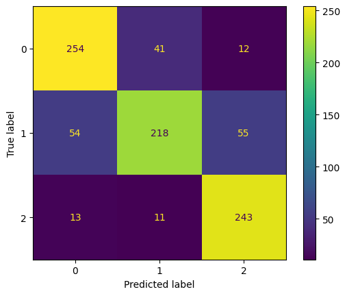

```python
from sklearn.metrics import ConfusionMatrixDisplay
cmN1 = metrics.confusion_matrix( true_labels, pred_test_labels)
metrics.ConfusionMatrixDisplay( cmN1 ).plot()
```

```python
from sklearn.metrics import classification_report
target_names = ['brain_glioma', 'brain_menin', 'brain_tumor']
print(classification_report(true_labels, pred_test_labels, target_names=target_names))
```

```
              precision    recall  f1-score   support

brain_glioma       0.79      0.83      0.81       307
 brain_menin       0.81      0.67      0.73       327
 brain_tumor       0.78      0.91      0.84       267

    accuracy                           0.79       901
   macro avg       0.79      0.80      0.79       901
weighted avg       0.79      0.79      0.79       901
```

Focusing on the “True Label = 1” we find that the model struggles to develop features that can distinguish true “brain_menin” instances from the other classes. This is particularly problematic, considering that “brain_glioma” and “brain_tumor” have minimal misclassifications of true class instances. Currently, the model has biased performance against patients with “brain-menin”. Its deployment in the current state would not be ethically justified from a virtue ethics point of view. Viewing the outcomes of the model from a virtue ethics perspective first requires defining the telos or purpose of the model. The purpose of the model can be defined as providing a tool to healthcare professionals to make faster, accurate, and reliable interpretations of MRI brain cancer imaging for early detection and improved prognosis. As such, it may be desired to uphold virtues such as fairness, truthfulness, and helpfulness to achieve this purpose. When deploying a model that has such disparate performance in detecting true instances of various types of cancer, multiple virtues become violated. At the forefront is the virtue of fairness, where patients who have “brain_tumor” or “brain_glioma” cancer types benefit more from the deployment of the model than patients with “brain_menin”. Truthfulness and helpfulness begin to be violated when patients receive incorrect diagnoses and treatment, potentially prolonging their road to recovery or worsening their situation. Due to these violations, we will attempt to create deeper and more sophisticated modeling architectures to close the performance gap, meet the model's purpose, and uphold virtues.

# Building functional convolutional neural network

## Creating a ResNet model architecture

ResNet is a variant architectural design of a convolutional neural network. ResNets, or residual networks, estimate a residual function instead of estimating the actual functions required to achieve maximal performance. More concretely, in a residual block, the output function is defined as $H(x) = F(x) + x$, where $H(x)$ is the output function, $F(x)$ is the residual function, and $x$ is the input. Instead of estimating $A(x)$ as is done in traditional networks, we instead learn a residual function $F(x)$, the error necessary in addition to the input to produce the output $H(x)$ (Sachan, 2026). The purpose of ResNets was to mitigate the degrading performance of extremely deep neural networks due to vanishing gradients.

ResNets mitigate the performance degradation issue by the use of shortcut paths during backpropagation. Normally, during backpropagation, the errors must propagate back through all the layers to compute the gradient of the loss with respect to the weights. The weights are adjusted in the direction of greatest decrease (i.e., the opposite of the gradient) and are scaled by the learning rate. The problem with deep networks is that the process of gradient determination becomes smaller and smaller as it reaches the input layer (Sachan, 2026). At this point, gradients at earlier layers are virtually zero and have a negligible impact on model weights. This is the vanishing gradient problem that has made training large neural networks challenging. ResNets mitigate this problem by introducing skip connections in residual blocks. Gradients can flow either through the residual function pathway or through the skip connections pathway (Sachan, 2026). When going through the residual function pathway, gradients do still become smaller and smaller. The skip connection pathway, also known as the identity mapping, allows the gradient to skip layers and reach the initial layers to help them learn the correct weights (Sachan, 2026).

In this project, we will be employing a variation of ResNets to improve upon the performance of our earlier architecture networks. The goal is to utilize this architectural design to create extremely deep networks to learn complex features and minimize the performance gap of label classifications. This will hopefully allow us to achieve a high-performance model that will be a useful tool for healthcare professionals in screening patients for cancer. More importantly, the improved performance will allow outcomes of the model to be fair, trustworthy, and helpful to patients experiencing any of the illnesses in this project.

### References

Sachan, A. (2026, March 12). CV-Tricks. Retrieved from https://cv-tricks.com/keras/understand-implement-resnets/

Adapted from: https://pylessons.com/Keras-ResNet-tutorial & https://cr-vision.carnotresearch.com/tutorials/cnn/resnet_from_scratch.html

```python
# Creating a identity block

def identity(input_tensor, f,filters, stage, block):
  '''
  Creating an identity block in a ResNet

  Parameters:
  data (tf.Data.dataset): The input tensor
  f (int): The middle convolutional layer kernel size
  filters (list): List composed of three integer elements to be passed to the keras.layers.Conv2D() argument "filters"
  stage (string): String to denote the stage of the indentity block in the ResNet
  block (string): String used to denote the block within a stage

  returns
  X (tensor): A tensor of shape (H,W,channels)
  '''

  # Creating a naming basis
  conv_name_base = 'res' + str(stage) + block + '_branch'
  # batchnorm_name_base = 'batch_norm' + str(stage) + str(block)

  # Extract filters
  filters_1, filters_2, filters_3 = filters

  # Shortcut value (input to skip over layers)
  x_shortcut = input_tensor

  # Creating first component
  x = keras.layers.Conv2D(filters=filters_1, kernel_size=(1,1), strides=(1,1), padding='valid', name=conv_name_base +'_a')(input_tensor)
  x = keras.layers.BatchNormalization(axis=3)(x)
  x = keras.layers.Activation(activation='relu')(x)

  # Creating second component
  x = keras.layers.Conv2D(filters=filters_2, kernel_size=(f,f), strides=(1,1), padding='same', name=conv_name_base +'_b')(x) # Padding is modified to same to ensure same tensor shape output
  x = keras.layers.BatchNormalization(axis=3)(x)
  x = keras.layers.Activation(activation='relu')(x)

  # Creating third component
  x = keras.layers.Conv2D(filters=filters_3, kernel_size=(1,1), strides=(1,1), padding='valid', name=conv_name_base +'_c')(x)
  x = keras.layers.BatchNormalization(axis=3)(x)
  x = keras.layers.Activation(activation='relu')(x)

  # # Adding input to main path output
  x = keras.layers.Add()([x, x_shortcut])
  x = keras.layers.Activation('relu')(x)

  # Return the tensor
  return x
```

```python
# Creating a small model to test the function
X_input = keras.layers.Input(shape=(512,512,128)) # Identity block needs to receive the same shape as the third component

x = keras.layers.ZeroPadding2D((3,3))(X_input) # padding for the middle conv layer

X = identity(x, 3,[32,64,128],'1','block_test')

model = keras.models.Model(X_input,X)

model.summary()
```

```
Model: "functional_3"
```

```
┏━━━━━━━━━━━━━━━━━━━━━┳━━━━━━━━━━━━━━━━━━━┳━━━━━━━━━━━━┳━━━━━━━━━━━━━━━━━━━┓
┃ Layer (type)        ┃ Output Shape      ┃    Param # ┃ Connected to      ┃
┡━━━━━━━━━━━━━━━━━━━━━╇━━━━━━━━━━━━━━━━━━━╇━━━━━━━━━━━━╇━━━━━━━━━━━━━━━━━━━┩
│ input_layer_3       │ (None, 512, 512,  │          0 │ -                 │
│ (InputLayer)        │ 128)              │            │                   │
├─────────────────────┼───────────────────┼────────────┼───────────────────┤
│ zero_padding2d      │ (None, 518, 518,  │          0 │ input_layer_3[0]… │
│ (ZeroPadding2D)     │ 128)              │            │                   │
├─────────────────────┼───────────────────┼────────────┼───────────────────┤
│ res1block_test_bra… │ (None, 518, 518,  │      4,128 │ zero_padding2d[0… │
│ (Conv2D)            │ 32)               │            │                   │
├─────────────────────┼───────────────────┼────────────┼───────────────────┤
│ batch_normalization │ (None, 518, 518,  │        128 │ res1block_test_b… │
│ (BatchNormalizatio… │ 32)               │            │                   │
├─────────────────────┼───────────────────┼────────────┼───────────────────┤
│ activation          │ (None, 518, 518,  │          0 │ batch_normalizat… │
│ (Activation)        │ 32)               │            │                   │
├─────────────────────┼───────────────────┼────────────┼───────────────────┤
│ res1block_test_bra… │ (None, 518, 518,  │     18,496 │ activation[0][0]  │
│ (Conv2D)            │ 64)               │            │                   │
├─────────────────────┼───────────────────┼────────────┼───────────────────┤
│ batch_normalizatio… │ (None, 518, 518,  │        256 │ res1block_test_b… │
│ (BatchNormalizatio… │ 64)               │            │                   │
├─────────────────────┼───────────────────┼────────────┼───────────────────┤
│ activation_1        │ (None, 518, 518,  │          0 │ batch_normalizat… │
│ (Activation)        │ 64)               │            │                   │
├─────────────────────┼───────────────────┼────────────┼───────────────────┤
│ res1block_test_bra… │ (None, 518, 518,  │      8,320 │ activation_1[0][… │
│ (Conv2D)            │ 128)              │            │                   │
├─────────────────────┼───────────────────┼────────────┼───────────────────┤
│ batch_normalizatio… │ (None, 518, 518,  │        512 │ res1block_test_b… │
│ (BatchNormalizatio… │ 128)              │            │                   │
├─────────────────────┼───────────────────┼────────────┼───────────────────┤
│ activation_2        │ (None, 518, 518,  │          0 │ batch_normalizat… │
│ (Activation)        │ 128)              │            │                   │
├─────────────────────┼───────────────────┼────────────┼───────────────────┤
│ add (Add)           │ (None, 518, 518,  │          0 │ activation_2[0][… │
│                     │ 128)              │            │ zero_padding2d[0… │
├─────────────────────┼───────────────────┼────────────┼───────────────────┤
│ activation_3        │ (None, 518, 518,  │          0 │ add[0][0]         │
│ (Activation)        │ 128)              │            │                   │
└─────────────────────┴───────────────────┴────────────┴───────────────────┘
```

```
 Total params: 31,840 (124.38 KB)
```

```
 Trainable params: 31,392 (122.62 KB)
```

```
 Non-trainable params: 448 (1.75 KB)
```

```python
# Creating a convolutional block

def convolution(input_tensor, f,filters, stage, block):
  '''
  Creating an convolution block in a ResNet. This block will change the dimensions of the shortcut tensor to match the shape of the main paths output

  Parameters:
  data (tf.Data.dataset): The input tensor
  f (int): The middle convolutional layer kernel size
  filters (list): List composed of three integer elements to be passed to the keras.layers.Conv2D() argument "filters"
  stage (string): String to denote the stage of the indentity block in the ResNet
  block (string): String used to denote the block within a stage

  returns
  X (tensor): A tensor of shape (H,W,channels)
  '''

  # Creating a naming basis
  conv_name_base = 'res' + str(stage) + block + '_branch'
  # batchnorm_name_base = 'batch_norm' + str(stage) + str(block)

  # Extract filters
  filters_1, filters_2, filters_3 = filters

  # Shortcut value (input to skip over layers)
  x_shortcut = input_tensor

  # Creating first component
  x = keras.layers.Conv2D(filters=filters_1, kernel_size=(1,1), strides=(1,1), padding='valid', name=conv_name_base +'_a')(input_tensor)
  x = keras.layers.BatchNormalization(axis=3)(x)
  x = keras.layers.Activation(activation='relu')(x)

  # Creating second component
  x = keras.layers.Conv2D(filters=filters_2, kernel_size=(f,f), strides=(1,1), padding='same', name=conv_name_base +'_b')(x) # Padding is modified to same to ensure same tensor shape output
  x = keras.layers.BatchNormalization(axis=3)(x)
  x = keras.layers.Activation(activation='relu')(x)

  # Creating third component
  x = keras.layers.Conv2D(filters=filters_3, kernel_size=(1,1), strides=(1,1), padding='valid', name=conv_name_base +'_c')(x)
  x = keras.layers.BatchNormalization(axis=3)(x)
  x = keras.layers.Activation(activation='relu')(x)

  # Modifying the dimensions of the shortcut input
  x_shortcut = keras.layers.Conv2D(filters=filters_3, kernel_size=(1,1))(x_shortcut)
  x_shortcut = keras.layers.BatchNormalization()(x_shortcut)
  # # Adding input to main path output
  x = keras.layers.Add()([x, x_shortcut])
  x = keras.layers.Activation('relu')(x)

  # Return the tensor
  return x
```

```python
# Creating a small model to test the function
X_input = keras.layers.Input(shape=(512,512,3)) # Identity block needs to receive the same shape as the third component

x = keras.layers.ZeroPadding2D((3,3))(X_input) # padding for the middle conv layer

X = convolution(x, 3,[32,64,128],'1','block_test')

model = keras.models.Model(X_input,X)

model.summary()
```

```
Model: "functional_4"
```

```
┏━━━━━━━━━━━━━━━━━━━━━┳━━━━━━━━━━━━━━━━━━━┳━━━━━━━━━━━━┳━━━━━━━━━━━━━━━━━━━┓
┃ Layer (type)        ┃ Output Shape      ┃    Param # ┃ Connected to      ┃
┡━━━━━━━━━━━━━━━━━━━━━╇━━━━━━━━━━━━━━━━━━━╇━━━━━━━━━━━━╇━━━━━━━━━━━━━━━━━━━┩
│ input_layer_4       │ (None, 512, 512,  │          0 │ -                 │
│ (InputLayer)        │ 3)                │            │                   │
├─────────────────────┼───────────────────┼────────────┼───────────────────┤
│ zero_padding2d_1    │ (None, 518, 518,  │          0 │ input_layer_4[0]… │
│ (ZeroPadding2D)     │ 3)                │            │                   │
├─────────────────────┼───────────────────┼────────────┼───────────────────┤
│ res1block_test_bra… │ (None, 518, 518,  │        128 │ zero_padding2d_1… │
│ (Conv2D)            │ 32)               │            │                   │
├─────────────────────┼───────────────────┼────────────┼───────────────────┤
│ batch_normalizatio… │ (None, 518, 518,  │        128 │ res1block_test_b… │
│ (BatchNormalizatio… │ 32)               │            │                   │
├─────────────────────┼───────────────────┼────────────┼───────────────────┤
│ activation_4        │ (None, 518, 518,  │          0 │ batch_normalizat… │
│ (Activation)        │ 32)               │            │                   │
├─────────────────────┼───────────────────┼────────────┼───────────────────┤
│ res1block_test_bra… │ (None, 518, 518,  │     18,496 │ activation_4[0][… │
│ (Conv2D)            │ 64)               │            │                   │
├─────────────────────┼───────────────────┼────────────┼───────────────────┤
│ batch_normalizatio… │ (None, 518, 518,  │        256 │ res1block_test_b… │
│ (BatchNormalizatio… │ 64)               │            │                   │
├─────────────────────┼───────────────────┼────────────┼───────────────────┤
│ activation_5        │ (None, 518, 518,  │          0 │ batch_normalizat… │
│ (Activation)        │ 64)               │            │                   │
├─────────────────────┼───────────────────┼────────────┼───────────────────┤
│ res1block_test_bra… │ (None, 518, 518,  │      8,320 │ activation_5[0][… │
│ (Conv2D)            │ 128)              │            │                   │
├─────────────────────┼───────────────────┼────────────┼───────────────────┤
│ batch_normalizatio… │ (None, 518, 518,  │        512 │ res1block_test_b… │
│ (BatchNormalizatio… │ 128)              │            │                   │
├─────────────────────┼───────────────────┼────────────┼───────────────────┤
│ conv2d_2 (Conv2D)   │ (None, 518, 518,  │        512 │ zero_padding2d_1… │
│                     │ 128)              │            │                   │
├─────────────────────┼───────────────────┼────────────┼───────────────────┤
│ activation_6        │ (None, 518, 518,  │          0 │ batch_normalizat… │
│ (Activation)        │ 128)              │            │                   │
├─────────────────────┼───────────────────┼────────────┼───────────────────┤
│ batch_normalizatio… │ (None, 518, 518,  │        512 │ conv2d_2[0][0]    │
│ (BatchNormalizatio… │ 128)              │            │                   │
├─────────────────────┼───────────────────┼────────────┼───────────────────┤
│ add_1 (Add)         │ (None, 518, 518,  │          0 │ activation_6[0][… │
│                     │ 128)              │            │ batch_normalizat… │
├─────────────────────┼───────────────────┼────────────┼───────────────────┤
│ activation_7        │ (None, 518, 518,  │          0 │ add_1[0][0]       │
│ (Activation)        │ 128)              │            │                   │
└─────────────────────┴───────────────────┴────────────┴───────────────────┘
```

```
 Total params: 28,864 (112.75 KB)
```

```
 Trainable params: 28,160 (110.00 KB)
```

```
 Non-trainable params: 704 (2.75 KB)
```

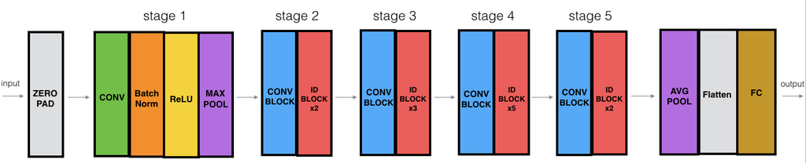

Above is the ResNet 50 architecture that inspired the modeling below. We will create two abbreviated variations of the ResNet 50 architecture. Both models will exclude the fifth stage, due to the lack of GPU RAM necessary for training. The first model will include stages 1-4, with stage four only having two identity layers. The second model will include all five identity layers to create an extremely deep neural network.

Building the ResNet model architecture

```python
from keras.layers import Conv2D, Dense, Input, ZeroPadding2D, Activation, MaxPool2D, AveragePooling2D, Flatten, BatchNormalization, RandomTranslation, RandomZoom
from keras.models import Model

# Creating symbolic input tensor
input = Input((512,512,3))

# Zero padding
x = ZeroPadding2D((3,3))(input) # Necessary because stage 1 convolution kernel is large and will reduce the tensor size due to a valid padding
x = keras.layers.Rescaling(1./255)(x)

# Adding data augmentation layer
x = RandomTranslation(height_factor=(-0.05, 0.05), width_factor=(-0.05, 0.05), fill_mode='constant', fill_value=0.0, seed=seed, data_format='channels_last')(x)
x = RandomZoom(height_factor=(-0.05, 0.05), width_factor=(-0.05, 0.05), fill_mode='constant', fill_value=0.0, seed=seed)(x)

# Creating stage 1 convolutional layer
x = Conv2D(filters=64,kernel_size=(7,7), strides=(2,2), padding='valid')(x)
x = BatchNormalization(axis=3)(x)
x = Activation('relu')(x)
x = MaxPool2D((3,3))(x)

# Stage 2
x = convolution(x, 3,[64,64,256],'2','a')
x = identity(x, 3,[64,64,256],'2','b')
x = identity(x, 3,[64,64,256],'2','c')

# Stage 3
x = convolution(x, 3,[128,128,512],'3','a')
x = identity(x, 3,[128,128,512],'3','b')
x = identity(x, 3,[128,128,512],'3' ,'c')
x = identity(x, 3,[128,128,512],'3' ,'d')

# Stage 4
x = convolution(x, 3,[256,256,1024],'4','a')
x = identity(x, 3,[256,256,1024],'4','b')
x = identity(x, 3,[256,256,1024],'4','c')
# x = identity(x, 3,[256,256,1024],'4','d')
# x = identity(x, 3,[256,256,1024],'4','e')
# x = identity(x, 3,[256,256,1024],'4','f')

# # Stage 5
# x = convolution(x, 3,[512,512,2048],'5','a')
# x = identity(x, 3,[512,512,2048],'5','b')
# x = identity(x, 3,[512,512,2048],'5','c')

# Applying Pooling
x = AveragePooling2D(pool_size=(2,2))(x)

# Flattening
y = Flatten()(x)

# Output layer
output = Dense(units=3, activation='softmax')(y)

# Creating model
model = Model(input, output)

# Model Summary
model.summary()
```

```
Model: "functional_5"
```

```
┏━━━━━━━━━━━━━━━━━━━━━┳━━━━━━━━━━━━━━━━━━━┳━━━━━━━━━━━━┳━━━━━━━━━━━━━━━━━━━┓
┃ Layer (type)        ┃ Output Shape      ┃    Param # ┃ Connected to      ┃
┡━━━━━━━━━━━━━━━━━━━━━╇━━━━━━━━━━━━━━━━━━━╇━━━━━━━━━━━━╇━━━━━━━━━━━━━━━━━━━┩
│ input_layer_5       │ (None, 512, 512,  │          0 │ -                 │
│ (InputLayer)        │ 3)                │            │                   │
├─────────────────────┼───────────────────┼────────────┼───────────────────┤
│ zero_padding2d_2    │ (None, 518, 518,  │          0 │ input_layer_5[0]… │
│ (ZeroPadding2D)     │ 3)                │            │                   │
├─────────────────────┼───────────────────┼────────────┼───────────────────┤
│ rescaling_3         │ (None, 518, 518,  │          0 │ zero_padding2d_2… │
│ (Rescaling)         │ 3)                │            │                   │
├─────────────────────┼───────────────────┼────────────┼───────────────────┤
│ random_translation… │ (None, 518, 518,  │          0 │ rescaling_3[0][0] │
│ (RandomTranslation) │ 3)                │            │                   │
├─────────────────────┼───────────────────┼────────────┼───────────────────┤
│ random_zoom_2       │ (None, 518, 518,  │          0 │ random_translati… │
│ (RandomZoom)        │ 3)                │            │                   │
├─────────────────────┼───────────────────┼────────────┼───────────────────┤
│ conv2d_3 (Conv2D)   │ (None, 256, 256,  │      9,472 │ random_zoom_2[0]… │
│                     │ 64)               │            │                   │
├─────────────────────┼───────────────────┼────────────┼───────────────────┤
│ batch_normalizatio… │ (None, 256, 256,  │        256 │ conv2d_3[0][0]    │
│ (BatchNormalizatio… │ 64)               │            │                   │
├─────────────────────┼───────────────────┼────────────┼───────────────────┤
│ activation_8        │ (None, 256, 256,  │          0 │ batch_normalizat… │
│ (Activation)        │ 64)               │            │                   │
├─────────────────────┼───────────────────┼────────────┼───────────────────┤
│ max_pooling2d_2     │ (None, 85, 85,    │          0 │ activation_8[0][… │
│ (MaxPooling2D)      │ 64)               │            │                   │
├─────────────────────┼───────────────────┼────────────┼───────────────────┤
│ res2a_branch_a      │ (None, 85, 85,    │      4,160 │ max_pooling2d_2[… │
│ (Conv2D)            │ 64)               │            │                   │
├─────────────────────┼───────────────────┼────────────┼───────────────────┤
│ batch_normalizatio… │ (None, 85, 85,    │        256 │ res2a_branch_a[0… │
│ (BatchNormalizatio… │ 64)               │            │                   │
├─────────────────────┼───────────────────┼────────────┼───────────────────┤
│ activation_9        │ (None, 85, 85,    │          0 │ batch_normalizat… │
│ (Activation)        │ 64)               │            │                   │
├─────────────────────┼───────────────────┼────────────┼───────────────────┤
│ res2a_branch_b      │ (None, 85, 85,    │     36,928 │ activation_9[0][… │
```

[output cut: 330 more lines]

```
│ (Activation)        │ 1024)             │            │                   │
├─────────────────────┼───────────────────┼────────────┼───────────────────┤
│ add_11 (Add)        │ (None, 85, 85,    │          0 │ activation_47[0]… │
│                     │ 1024)             │            │ activation_44[0]… │
├─────────────────────┼───────────────────┼────────────┼───────────────────┤
│ activation_48       │ (None, 85, 85,    │          0 │ add_11[0][0]      │
│ (Activation)        │ 1024)             │            │                   │
├─────────────────────┼───────────────────┼────────────┼───────────────────┤
│ average_pooling2d   │ (None, 42, 42,    │          0 │ activation_48[0]… │
│ (AveragePooling2D)  │ 1024)             │            │                   │
├─────────────────────┼───────────────────┼────────────┼───────────────────┤
│ flatten_3 (Flatten) │ (None, 1806336)   │          0 │ average_pooling2… │
├─────────────────────┼───────────────────┼────────────┼───────────────────┤
│ dense_8 (Dense)     │ (None, 3)         │  5,419,011 │ flatten_3[0][0]   │
└─────────────────────┴───────────────────┴────────────┴───────────────────┘
```

```
 Total params: 10,642,819 (40.60 MB)
```

```
 Trainable params: 10,621,443 (40.52 MB)
```

```
 Non-trainable params: 21,376 (83.50 KB)
```

```python
# Compiling model
model.compile(loss='sparse_categorical_crossentropy', metrics=['accuracy'])
```

```python
from keras.callbacks import EarlyStopping
early_stopping = EarlyStopping(
    monitor='val_loss',  # Monitor validation loss
    patience=10,          # Stop after 10 epochs with no min delta improvement
    min_delta=0.001,     # Minimum change to qualify as improvement
    verbose=2,           # Display messages when callback takes action
    restore_best_weights=True # Restore weights from the best epoch
)
```

```python
# Fitting model
model.fit(train_ds, batch_size=128, epochs=50, validation_data=val_ds, callbacks=[early_stopping, performance_eval])
```

```
132/132 ━━━━━━━━━━━━━━━━━━━━ 115s 662ms/step - accuracy: 0.4815 - loss: 391.8670 - val_accuracy: 0.3525 - val_loss: 17.6389
132/132 ━━━━━━━━━━━━━━━━━━━━ 77s 586ms/step - accuracy: 0.6028 - loss: 28.4623 - val_accuracy: 0.4324 - val_loss: 13.4261
132/132 ━━━━━━━━━━━━━━━━━━━━ 77s 586ms/step - accuracy: 0.6751 - loss: 5.8273 - val_accuracy: 0.4135 - val_loss: 7.5781
132/132 ━━━━━━━━━━━━━━━━━━━━ 78s 588ms/step - accuracy: 0.6108 - loss: 198.9032 - val_accuracy: 0.3514 - val_loss: 8.8412
132/132 ━━━━━━━━━━━━━━━━━━━━ 77s 586ms/step - accuracy: 0.7101 - loss: 3.4742 - val_accuracy: 0.3359 - val_loss: 69.2727
132/132 ━━━━━━━━━━━━━━━━━━━━ 77s 585ms/step - accuracy: 0.7514 - loss: 2.2167 - val_accuracy: 0.4257 - val_loss: 20.1271
132/132 ━━━━━━━━━━━━━━━━━━━━ 77s 586ms/step - accuracy: 0.7654 - loss: 1.0038 - val_accuracy: 0.6896 - val_loss: 6.1245
132/132 ━━━━━━━━━━━━━━━━━━━━ 77s 586ms/step - accuracy: 0.7970 - loss: 0.5353 - val_accuracy: 0.6763 - val_loss: 5.2832
132/132 ━━━━━━━━━━━━━━━━━━━━ 77s 585ms/step - accuracy: 0.8374 - loss: 0.5940 - val_accuracy: 0.4878 - val_loss: 2.4124
132/132 ━━━━━━━━━━━━━━━━━━━━ 77s 585ms/step - accuracy: 0.8448 - loss: 0.9555 - val_accuracy: 0.4978 - val_loss: 2.9912
132/132 ━━━━━━━━━━━━━━━━━━━━ 77s 585ms/step - accuracy: 0.8367 - loss: 0.4658 - val_accuracy: 0.4945 - val_loss: 5.6587
132/132 ━━━━━━━━━━━━━━━━━━━━ 77s 585ms/step - accuracy: 0.8635 - loss: 0.3616 - val_accuracy: 0.5366 - val_loss: 2.3537
132/132 ━━━━━━━━━━━━━━━━━━━━ 77s 585ms/step - accuracy: 0.8641 - loss: 0.7719 - val_accuracy: 0.5743 - val_loss: 2.2391
132/132 ━━━━━━━━━━━━━━━━━━━━ 77s 584ms/step - accuracy: 0.8755 - loss: 0.3308 - val_accuracy: 0.4246 - val_loss: 3.8465
132/132 ━━━━━━━━━━━━━━━━━━━━ 77s 585ms/step - accuracy: 0.8895 - loss: 0.2933 - val_accuracy: 0.5521 - val_loss: 2.1142
132/132 ━━━━━━━━━━━━━━━━━━━━ 77s 585ms/step - accuracy: 0.8972 - loss: 0.4394 - val_accuracy: 0.5953 - val_loss: 1.1971
132/132 ━━━━━━━━━━━━━━━━━━━━ 77s 585ms/step - accuracy: 0.9047 - loss: 0.2501 - val_accuracy: 0.6685 - val_loss: 1.5732
132/132 ━━━━━━━━━━━━━━━━━━━━ 77s 585ms/step - accuracy: 0.9130 - loss: 0.2385 - val_accuracy: 0.6885 - val_loss: 0.9334
132/132 ━━━━━━━━━━━━━━━━━━━━ 77s 585ms/step - accuracy: 0.9143 - loss: 0.2310 - val_accuracy: 0.5122 - val_loss: 2.4614
132/132 ━━━━━━━━━━━━━━━━━━━━ 77s 585ms/step - accuracy: 0.9194 - loss: 0.2301 - val_accuracy: 0.6796 - val_loss: 1.6133
132/132 ━━━━━━━━━━━━━━━━━━━━ 77s 585ms/step - accuracy: 0.9268 - loss: 0.2042 - val_accuracy: 0.8293 - val_loss: 0.6370
132/132 ━━━━━━━━━━━━━━━━━━━━ 77s 585ms/step - accuracy: 0.9332 - loss: 0.1861 - val_accuracy: 0.4346 - val_loss: 11.2261
132/132 ━━━━━━━━━━━━━━━━━━━━ 77s 585ms/step - accuracy: 0.9283 - loss: 0.1991 - val_accuracy: 0.7262 - val_loss: 1.0128
132/132 ━━━━━━━━━━━━━━━━━━━━ 77s 585ms/step - accuracy: 0.9333 - loss: 0.1798 - val_accuracy: 0.8370 - val_loss: 0.4800
132/132 ━━━━━━━━━━━━━━━━━━━━ 77s 585ms/step - accuracy: 0.9308 - loss: 0.1882 - val_accuracy: 0.5898 - val_loss: 2.2321
132/132 ━━━━━━━━━━━━━━━━━━━━ 77s 585ms/step - accuracy: 0.9402 - loss: 0.1626 - val_accuracy: 0.5377 - val_loss: 4.4841
132/132 ━━━━━━━━━━━━━━━━━━━━ 77s 585ms/step - accuracy: 0.9489 - loss: 0.1436 - val_accuracy: 0.8182 - val_loss: 0.5452
132/132 ━━━━━━━━━━━━━━━━━━━━ 77s 585ms/step - accuracy: 0.9492 - loss: 0.1317 - val_accuracy: 0.8016 - val_loss: 0.6549
132/132 ━━━━━━━━━━━━━━━━━━━━ 77s 585ms/step - accuracy: 0.9475 - loss: 0.1396 - val_accuracy: 0.7007 - val_loss: 2.1231
132/132 ━━━━━━━━━━━━━━━━━━━━ 77s 585ms/step - accuracy: 0.9542 - loss: 0.1241 - val_accuracy: 0.4645 - val_loss: 10.3802
132/132 ━━━━━━━━━━━━━━━━━━━━ 77s 585ms/step - accuracy: 0.9563 - loss: 0.1217 - val_accuracy: 0.5133 - val_loss: 3.2913
132/132 ━━━━━━━━━━━━━━━━━━━━ 77s 585ms/step - accuracy: 0.9434 - loss: 0.1378 - val_accuracy: 0.6142 - val_loss: 3.0988
132/132 ━━━━━━━━━━━━━━━━━━━━ 77s 586ms/step - accuracy: 0.9597 - loss: 0.1207 - val_accuracy: 0.8581 - val_loss: 0.4352
132/132 ━━━━━━━━━━━━━━━━━━━━ 77s 585ms/step - accuracy: 0.9518 - loss: 0.1292 - val_accuracy: 0.6375 - val_loss: 3.3722
```

[output cut: 17 more lines]

```
<keras.src.callbacks.history.History at 0x7e7f71922480>
```

```python
# Loading the tensorboard extension
%load_ext tensorboard
```

```
The tensorboard extension is already loaded. To reload it, use:
  %reload_ext tensorboard
```

```python
%tensorboard --logdir logs
```

```
Reusing TensorBoard on port 6006 (pid 34020), started 1:15:33 ago. (Use '!kill 34020' to kill it.)
```

```python
pred_test = model.predict(test_ds)
```

```
29/29 ━━━━━━━━━━━━━━━━━━━━ 6s 180ms/step
```

```python
# Extracting the predicted labels
pred_test_labels = numpy.argmax(pred_test, axis=1)
```

```python
# Viewing balance accruacy
print(metrics.balanced_accuracy_score(true_labels, pred_test_labels))
```

```
0.9373306750597852
```

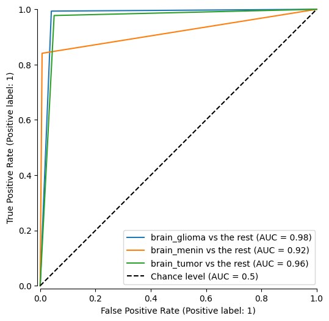

```python
# Creating a AUC curve
from sklearn.preprocessing import LabelBinarizer
lb = LabelBinarizer()
lb.fit(true_labels)
binarized_labels_true = lb.transform(true_labels)
binarized_labels = lb.transform(pred_test_labels)


# Extracting class names
class_names = ['brain_glioma', 'brain_menin', 'brain_tumor']

fig, ax = plt.subplots(figsize=(6, 6))

RocCurveDisplay.from_predictions(
  binarized_labels_true[:,0],
  binarized_labels[:,0],
  name=f'{class_names[0]} vs the rest',
  ax=ax,
  despine=True
)

RocCurveDisplay.from_predictions(
  binarized_labels_true[:,1],
  binarized_labels[:,1],
  name=f'{class_names[1]} vs the rest',
  despine=True,
  ax=ax
)

RocCurveDisplay.from_predictions(
  binarized_labels_true[:,2],
  binarized_labels[:,2],
  name=f'{class_names[2]} vs the rest',
  despine=True,
  plot_chance_level = True,
  ax=ax
)


plt.show()
```

Reviewing the ROC graph shows that our ResNet model has massive performance capabilities compared to our baseline and convolutional network. The AUC for “brain_glioma” is $0.98$, which is very close to a perfect classifier. Runner up in high discriminatory ability is the “brain_tumor” class with an AUC of $0.96$. A notable performance improvement is for the “brain_menin” class ($AUC=0.92$) compared to its baseline levels ($AUC =0.75$). The $22$% increase in discriminatory power from the baseline level makes the classifier of excellent quality. Diving into the more granular details, we find that lowering the classification threshold slightly captures more than $80$% of the true “brain_menin” instances, suggesting that the model has high precision for the target label. Although to capture all true positives of the class instance, the model introduces meaningful amounts of false positives, suggesting a strong but lower class recall rate. The other two classes demonstrate a strong performance by capturing most true positives with a minimal decrease in classification thresholds. This suggests a strong precision, recall, and well-rounded F1-score.

```
<sklearn.metrics._plot.confusion_matrix.ConfusionMatrixDisplay at 0x7e811f87a780>
```

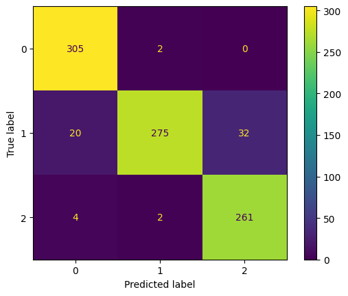

```python
from sklearn.metrics import ConfusionMatrixDisplay
cmN1 = metrics.confusion_matrix( true_labels, pred_test_labels)
metrics.ConfusionMatrixDisplay( cmN1 ).plot()
```

```python
from sklearn.metrics import classification_report
target_names = ['brain_glioma', 'brain_menin', 'brain_tumor']
print(classification_report(true_labels, pred_test_labels, target_names=target_names))
```

```
              precision    recall  f1-score   support

brain_glioma       0.93      0.99      0.96       307
 brain_menin       0.99      0.84      0.91       327
 brain_tumor       0.89      0.98      0.93       267

    accuracy                           0.93       901
   macro avg       0.93      0.94      0.93       901
weighted avg       0.94      0.93      0.93       901
```

```python
model.save('ResNet_mini.keras')
```

Diving into the recall and precision statistics reveals the strong discriminatory ability of the model. Precision of the model across all classes is strong with “brain_menin” achieving a $99$% precision statistic. This means that given a positive “brain_menin” prediction, there is a high degree of certainty that the prediction is correct. We can visualize this performance in the confusion matrix, where given a predicted label of “1” or “brain_menin”, only $\frac{4}{279}$ were false positives. For “brain_tumor” $(precision=0.89)$ predictions, label “2” on the confusion matrix, the model perfectly distiguishes between “brain_glioma” and “brain_tumor”. It struggles with discriminating between “brain_menin” and “brain_tumor”. This information can be utilized for model improvement. Perhaps creating a deeper neural network may aid in creating increasingly complex features to better discriminate between the two. The “brain_glioma” $(precision=0.93)$ shows strong precision by misclassifying only 24 of the predicted “brain_glioma” instances. Moving on to recall, we find that the classifier captures $99$% of all true “brain_glioma” class instances. Similarly, the classifier does a tremendous job of capturing $98$% of all “brain_tumor” class instances. With regards to the “brain_menin” ($recall=0.84$) class, the classifier experienced $52$% increase in recall performance from baseline levels. This dramatic increase in performance helps close in the performance gap across illnesses aligning the model to achieve its purpose and upholding the virtues of fairness, helpfulness, and truthfulness to end users.

Continuing with the project, we will create a deeper neural network in the next section. This is conducted in an attempt improve the recall statistic of the "brain_menin" class.

# Extremely deep CNN

```python
from keras.layers import Conv2D, Dense, Input, ZeroPadding2D, Activation, MaxPool2D, AveragePooling2D, Flatten, BatchNormalization, RandomTranslation, RandomZoom
from keras.models import Model

# Creating symbolic input tensor
input = Input((512,512,3))

# Zero padding
x = ZeroPadding2D((3,3))(input) # Necessary because stage 1 convolution kernel is large and will reduce the tensor size due to a valid padding
x = keras.layers.Rescaling(1./255)(x)

# Adding data augmentation layer
x = RandomTranslation(height_factor=(-0.05, 0.05), width_factor=(-0.05, 0.05), fill_mode='constant', fill_value=0.0, seed=seed, data_format='channels_last')(x)
x = RandomZoom(height_factor=(-0.05, 0.05), width_factor=(-0.05, 0.05), fill_mode='constant', fill_value=0.0, seed=seed)(x)

# Creating stage 1 convolutional layer
x = Conv2D(filters=64,kernel_size=(7,7), strides=(2,2), padding='valid')(x)
x = BatchNormalization(axis=3)(x)
x = Activation('relu')(x)
x = MaxPool2D((3,3))(x)

# Stage 2
x = convolution(x, 3,[64,64,256],'2','a')
x = identity(x, 3,[64,64,256],'2','b')
x = identity(x, 3,[64,64,256],'2','c')

# Stage 3
x = convolution(x, 3,[128,128,512],'3','a')
x = identity(x, 3,[128,128,512],'3','b')
x = identity(x, 3,[128,128,512],'3' ,'c')
x = identity(x, 3,[128,128,512],'3' ,'d')

# Stage 4
x = convolution(x, 3,[256,256,1024],'4','a')
x = identity(x, 3,[256,256,1024],'4','b')
x = identity(x, 3,[256,256,1024],'4','c')
x = identity(x, 3,[256,256,1024],'4','d')
x = identity(x, 3,[256,256,1024],'4','e')
x = identity(x, 3,[256,256,1024],'4','f')

# # Stage 5
# x = convolution(x, 3,[512,512,2048],'5','a')
# x = identity(x, 3,[512,512,2048],'5','b')
# x = identity(x, 3,[512,512,2048],'5','c')

# Applying Pooling
x = AveragePooling2D(pool_size=(2,2))(x)

# Flattening
y = Flatten()(x)

# Output layer
output = Dense(units=3, activation='softmax')(y)

# Creating model
model = Model(input, output)

# Model Summary
model.summary()
```

```
Model: "functional_6"
```

```
┏━━━━━━━━━━━━━━━━━━━━━┳━━━━━━━━━━━━━━━━━━━┳━━━━━━━━━━━━┳━━━━━━━━━━━━━━━━━━━┓
┃ Layer (type)        ┃ Output Shape      ┃    Param # ┃ Connected to      ┃
┡━━━━━━━━━━━━━━━━━━━━━╇━━━━━━━━━━━━━━━━━━━╇━━━━━━━━━━━━╇━━━━━━━━━━━━━━━━━━━┩
│ input_layer_6       │ (None, 512, 512,  │          0 │ -                 │
│ (InputLayer)        │ 3)                │            │                   │
├─────────────────────┼───────────────────┼────────────┼───────────────────┤
│ zero_padding2d_3    │ (None, 518, 518,  │          0 │ input_layer_6[0]… │
│ (ZeroPadding2D)     │ 3)                │            │                   │
├─────────────────────┼───────────────────┼────────────┼───────────────────┤
│ rescaling_4         │ (None, 518, 518,  │          0 │ zero_padding2d_3… │
│ (Rescaling)         │ 3)                │            │                   │
├─────────────────────┼───────────────────┼────────────┼───────────────────┤
│ random_translation… │ (None, 518, 518,  │          0 │ rescaling_4[0][0] │
│ (RandomTranslation) │ 3)                │            │                   │
├─────────────────────┼───────────────────┼────────────┼───────────────────┤
│ random_zoom_3       │ (None, 518, 518,  │          0 │ random_translati… │
│ (RandomZoom)        │ 3)                │            │                   │
├─────────────────────┼───────────────────┼────────────┼───────────────────┤
│ conv2d_7 (Conv2D)   │ (None, 256, 256,  │      9,472 │ random_zoom_3[0]… │
│                     │ 64)               │            │                   │
├─────────────────────┼───────────────────┼────────────┼───────────────────┤
│ batch_normalizatio… │ (None, 256, 256,  │        256 │ conv2d_7[0][0]    │
│ (BatchNormalizatio… │ 64)               │            │                   │
├─────────────────────┼───────────────────┼────────────┼───────────────────┤
│ activation_49       │ (None, 256, 256,  │          0 │ batch_normalizat… │
│ (Activation)        │ 64)               │            │                   │
├─────────────────────┼───────────────────┼────────────┼───────────────────┤
│ max_pooling2d_3     │ (None, 85, 85,    │          0 │ activation_49[0]… │
│ (MaxPooling2D)      │ 64)               │            │                   │
├─────────────────────┼───────────────────┼────────────┼───────────────────┤
│ res2a_branch_a      │ (None, 85, 85,    │      4,160 │ max_pooling2d_3[… │
│ (Conv2D)            │ 64)               │            │                   │
├─────────────────────┼───────────────────┼────────────┼───────────────────┤
│ batch_normalizatio… │ (None, 85, 85,    │        256 │ res2a_branch_a[0… │
│ (BatchNormalizatio… │ 64)               │            │                   │
├─────────────────────┼───────────────────┼────────────┼───────────────────┤
│ activation_50       │ (None, 85, 85,    │          0 │ batch_normalizat… │
│ (Activation)        │ 64)               │            │                   │
├─────────────────────┼───────────────────┼────────────┼───────────────────┤
│ res2a_branch_b      │ (None, 85, 85,    │     36,928 │ activation_50[0]… │
```

[output cut: 429 more lines]

```
│ (Activation)        │ 1024)             │            │                   │
├─────────────────────┼───────────────────┼────────────┼───────────────────┤
│ add_24 (Add)        │ (None, 85, 85,    │          0 │ activation_100[0… │
│                     │ 1024)             │            │ activation_97[0]… │
├─────────────────────┼───────────────────┼────────────┼───────────────────┤
│ activation_101      │ (None, 85, 85,    │          0 │ add_24[0][0]      │
│ (Activation)        │ 1024)             │            │                   │
├─────────────────────┼───────────────────┼────────────┼───────────────────┤
│ average_pooling2d_1 │ (None, 42, 42,    │          0 │ activation_101[0… │
│ (AveragePooling2D)  │ 1024)             │            │                   │
├─────────────────────┼───────────────────┼────────────┼───────────────────┤
│ flatten_4 (Flatten) │ (None, 1806336)   │          0 │ average_pooling2… │
├─────────────────────┼───────────────────┼────────────┼───────────────────┤
│ dense_9 (Dense)     │ (None, 3)         │  5,419,011 │ flatten_4[0][0]   │
└─────────────────────┴───────────────────┴────────────┴───────────────────┘
```

```
 Total params: 14,008,195 (53.44 MB)
```

```
 Trainable params: 13,977,603 (53.32 MB)
```

```
 Non-trainable params: 30,592 (119.50 KB)
```

```python
# Compiling model
model.compile(loss='sparse_categorical_crossentropy', metrics=['accuracy'])
```

```python
model.fit(train_ds, batch_size=128, epochs=50, validation_data=val_ds, callbacks=[early_stopping, performance_eval])
```

```
132/132 ━━━━━━━━━━━━━━━━━━━━ 131s 837ms/step - accuracy: 0.4481 - loss: 695.6475 - val_accuracy: 0.3836 - val_loss: 11.8240
132/132 ━━━━━━━━━━━━━━━━━━━━ 108s 820ms/step - accuracy: 0.6535 - loss: 2.8225 - val_accuracy: 0.3503 - val_loss: 30.4247
132/132 ━━━━━━━━━━━━━━━━━━━━ 108s 820ms/step - accuracy: 0.7208 - loss: 0.8778 - val_accuracy: 0.5565 - val_loss: 1.0246
132/132 ━━━━━━━━━━━━━━━━━━━━ 108s 820ms/step - accuracy: 0.7519 - loss: 0.6555 - val_accuracy: 0.5333 - val_loss: 2.4991
132/132 ━━━━━━━━━━━━━━━━━━━━ 108s 821ms/step - accuracy: 0.7699 - loss: 2.5057 - val_accuracy: 0.6098 - val_loss: 0.9459
132/132 ━━━━━━━━━━━━━━━━━━━━ 108s 820ms/step - accuracy: 0.8137 - loss: 0.5348 - val_accuracy: 0.5188 - val_loss: 3.5352
132/132 ━━━━━━━━━━━━━━━━━━━━ 108s 820ms/step - accuracy: 0.8196 - loss: 0.4672 - val_accuracy: 0.6009 - val_loss: 1.2095
132/132 ━━━━━━━━━━━━━━━━━━━━ 108s 820ms/step - accuracy: 0.8420 - loss: 0.4107 - val_accuracy: 0.4457 - val_loss: 7.1949
132/132 ━━━━━━━━━━━━━━━━━━━━ 108s 820ms/step - accuracy: 0.8295 - loss: 0.5167 - val_accuracy: 0.5865 - val_loss: 1.2294
132/132 ━━━━━━━━━━━━━━━━━━━━ 108s 820ms/step - accuracy: 0.8679 - loss: 0.3734 - val_accuracy: 0.6774 - val_loss: 1.0348
132/132 ━━━━━━━━━━━━━━━━━━━━ 108s 820ms/step - accuracy: 0.8800 - loss: 0.3213 - val_accuracy: 0.5455 - val_loss: 1.9547
132/132 ━━━━━━━━━━━━━━━━━━━━ 108s 821ms/step - accuracy: 0.8774 - loss: 0.4884 - val_accuracy: 0.8126 - val_loss: 0.5082
132/132 ━━━━━━━━━━━━━━━━━━━━ 108s 820ms/step - accuracy: 0.8914 - loss: 0.3111 - val_accuracy: 0.6197 - val_loss: 1.1069
132/132 ━━━━━━━━━━━━━━━━━━━━ 108s 820ms/step - accuracy: 0.9102 - loss: 0.2963 - val_accuracy: 0.6619 - val_loss: 1.0338
132/132 ━━━━━━━━━━━━━━━━━━━━ 108s 820ms/step - accuracy: 0.9105 - loss: 1.4384 - val_accuracy: 0.4922 - val_loss: 2.0671
132/132 ━━━━━━━━━━━━━━━━━━━━ 108s 820ms/step - accuracy: 0.9047 - loss: 0.2452 - val_accuracy: 0.4468 - val_loss: 2.5530
132/132 ━━━━━━━━━━━━━━━━━━━━ 108s 820ms/step - accuracy: 0.9286 - loss: 0.2083 - val_accuracy: 0.6430 - val_loss: 1.3858
132/132 ━━━━━━━━━━━━━━━━━━━━ 108s 821ms/step - accuracy: 0.9264 - loss: 0.2071 - val_accuracy: 0.8548 - val_loss: 0.4305
132/132 ━━━━━━━━━━━━━━━━━━━━ 108s 821ms/step - accuracy: 0.9268 - loss: 0.1977 - val_accuracy: 0.9002 - val_loss: 0.2948
132/132 ━━━━━━━━━━━━━━━━━━━━ 108s 819ms/step - accuracy: 0.9382 - loss: 0.1954 - val_accuracy: 0.5920 - val_loss: 1.9056
132/132 ━━━━━━━━━━━━━━━━━━━━ 108s 820ms/step - accuracy: 0.9374 - loss: 0.1762 - val_accuracy: 0.6707 - val_loss: 1.4396
132/132 ━━━━━━━━━━━━━━━━━━━━ 108s 820ms/step - accuracy: 0.9433 - loss: 0.1682 - val_accuracy: 0.5233 - val_loss: 2.4581
132/132 ━━━━━━━━━━━━━━━━━━━━ 108s 820ms/step - accuracy: 0.9251 - loss: 0.2597 - val_accuracy: 0.5953 - val_loss: 2.9344
132/132 ━━━━━━━━━━━━━━━━━━━━ 108s 820ms/step - accuracy: 0.9369 - loss: 0.1699 - val_accuracy: 0.8016 - val_loss: 0.7565
132/132 ━━━━━━━━━━━━━━━━━━━━ 108s 820ms/step - accuracy: 0.9341 - loss: 0.1690 - val_accuracy: 0.5200 - val_loss: 3.5753
132/132 ━━━━━━━━━━━━━━━━━━━━ 108s 820ms/step - accuracy: 0.9487 - loss: 0.1520 - val_accuracy: 0.6718 - val_loss: 1.6715
132/132 ━━━━━━━━━━━━━━━━━━━━ 108s 820ms/step - accuracy: 0.9493 - loss: 0.1372 - val_accuracy: 0.7417 - val_loss: 0.8596
132/132 ━━━━━━━━━━━━━━━━━━━━ 108s 821ms/step - accuracy: 0.9544 - loss: 0.1359 - val_accuracy: 0.9091 - val_loss: 0.2510
132/132 ━━━━━━━━━━━━━━━━━━━━ 108s 820ms/step - accuracy: 0.9497 - loss: 0.1359 - val_accuracy: 0.6984 - val_loss: 1.1484
132/132 ━━━━━━━━━━━━━━━━━━━━ 108s 820ms/step - accuracy: 0.9560 - loss: 0.3171 - val_accuracy: 0.6430 - val_loss: 1.6873
132/132 ━━━━━━━━━━━━━━━━━━━━ 108s 820ms/step - accuracy: 0.9646 - loss: 0.1099 - val_accuracy: 0.4656 - val_loss: 24.9813
132/132 ━━━━━━━━━━━━━━━━━━━━ 108s 820ms/step - accuracy: 0.9582 - loss: 0.1227 - val_accuracy: 0.6341 - val_loss: 5.2004
132/132 ━━━━━━━━━━━━━━━━━━━━ 108s 820ms/step - accuracy: 0.9612 - loss: 0.2244 - val_accuracy: 0.6530 - val_loss: 7.0038
132/132 ━━━━━━━━━━━━━━━━━━━━ 108s 820ms/step - accuracy: 0.9649 - loss: 0.1047 - val_accuracy: 0.7849 - val_loss: 0.7191
132/132 ━━━━━━━━━━━━━━━━━━━━ 108s 820ms/step - accuracy: 0.9652 - loss: 0.1009 - val_accuracy: 0.5288 - val_loss: 6.1510
132/132 ━━━━━━━━━━━━━━━━━━━━ 108s 819ms/step - accuracy: 0.9654 - loss: 0.1025 - val_accuracy: 0.7517 - val_loss: 1.4816
132/132 ━━━━━━━━━━━━━━━━━━━━ 108s 820ms/step - accuracy: 0.9691 - loss: 0.1137 - val_accuracy: 0.6918 - val_loss: 1.3651
132/132 ━━━━━━━━━━━━━━━━━━━━ 108s 820ms/step - accuracy: 0.9700 - loss: 0.0847 - val_accuracy: 0.6519 - val_loss: 1.8604
Epoch 38: early stopping
Restoring model weights from the end of the best epoch: 28.
```

```
<keras.src.callbacks.history.History at 0x7e7f9c2d7890>
```

```python
# Loading the tensorboard extension
%load_ext tensorboard
```

```
The tensorboard extension is already loaded. To reload it, use:
  %reload_ext tensorboard
```

```python
%tensorboard --logdir logs
```

```
Reusing TensorBoard on port 6006 (pid 34020), started 2:24:37 ago. (Use '!kill 34020' to kill it.)
```

```python
pred_test = model.predict(test_ds)
```

```
29/29 ━━━━━━━━━━━━━━━━━━━━ 8s 222ms/step
```

```python
# Extracting the predicted labels
pred_test_labels = numpy.argmax(pred_test, axis=1)
```

```python
# Viewing balance accruacy
print(metrics.balanced_accuracy_score(true_labels, pred_test_labels))
```

```
0.907650512913008
```

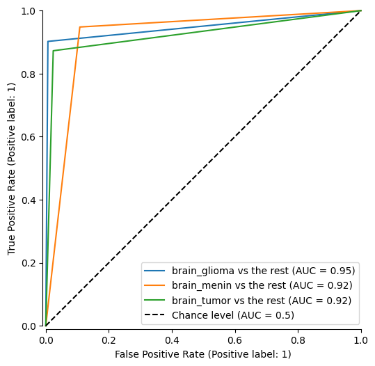

```python
# Creating a AUC curve
from sklearn.preprocessing import LabelBinarizer
lb = LabelBinarizer()
lb.fit(true_labels)
binarized_labels_true = lb.transform(true_labels)
binarized_labels = lb.transform(pred_test_labels)


# Extracting class names
class_names = ['brain_glioma', 'brain_menin', 'brain_tumor']

fig, ax = plt.subplots(figsize=(6, 6))

RocCurveDisplay.from_predictions(
  binarized_labels_true[:,0],
  binarized_labels[:,0],
  name=f'{class_names[0]} vs the rest',
  ax=ax,
  despine=True
)

RocCurveDisplay.from_predictions(
  binarized_labels_true[:,1],
  binarized_labels[:,1],
  name=f'{class_names[1]} vs the rest',
  despine=True,
  ax=ax
)

RocCurveDisplay.from_predictions(
  binarized_labels_true[:,2],
  binarized_labels[:,2],
  name=f'{class_names[2]} vs the rest',
  despine=True,
  plot_chance_level = True,
  ax=ax
)


plt.show()
```

```
<sklearn.metrics._plot.confusion_matrix.ConfusionMatrixDisplay at 0x7e7cf47a83e0>
```

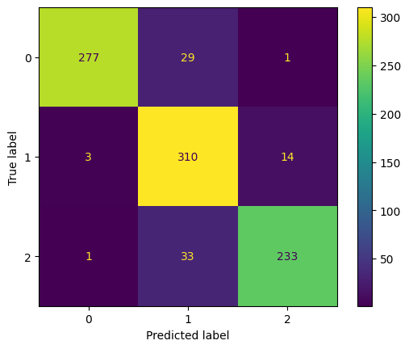

```python
from sklearn.metrics import ConfusionMatrixDisplay
cmN1 = metrics.confusion_matrix( true_labels, pred_test_labels)
metrics.ConfusionMatrixDisplay( cmN1 ).plot()
```

```python
from sklearn.metrics import classification_report
target_names = ['brain_glioma', 'brain_menin', 'brain_tumor']
print(classification_report(true_labels, pred_test_labels, target_names=target_names))
```

```
              precision    recall  f1-score   support

brain_glioma       0.99      0.90      0.94       307
 brain_menin       0.83      0.95      0.89       327
 brain_tumor       0.94      0.87      0.90       267

    accuracy                           0.91       901
   macro avg       0.92      0.91      0.91       901
weighted avg       0.92      0.91      0.91       901
```

```python
model.save('ResNet_deep.keras')
```

Reviewing the classification report statistics reveals interesting properties of the deep ResNet model. The F1-score across classes is robust, although it does not reach the levels set by the simpler ResNet architecture. Analyzing the precision statistics in comparison to the previous ResNet model, we find improvements in performance for the “brain_glioma” ($precision=0.99$) and “brain_tumor” ($precision=0.94$) classes. The confusion matrix reveals that “brain_glioma” predictions have become more accurate, addressing the “brain_menin” misclassifications for the less complex ResNet model. Similarly, the “brain_tumor” predictions have mitigated some of the false positives previously seen with “brain_menin” instances. It accomplished this while still maintaining “brain_glioma” false positives to a minimum. Predictions of “brain_menin” are introducing more misclassifications, shown in the confusion matrix. This is reflected in the precision metric of $0.83$. The recall statistics across the classes remain robust. Moderate improvements in this statistic are made for the “brain_menin” class compared to the less complex ResNet model. Although we find that the recall statistic declines for the other two classes. Looking at the confusion matrix, it appears that most misclassifications of “brain_glioma” and “brain_tumor” are due to “brain_menin” predictions.

Overall, the deep ResNet model is a strong classifier. Compared to the baseline, the model makes tremendous improvements in predictive power. The residual network learns a residual function, and each residual block has a skip connection to mitigate the vanishing gradient problem of deep networks. In comparison to the less complex ResNet model, we found that deeper layers did not necessarily improve the model. It improved the recall score of the “brain_menin” class, as set out in the previous section, but did so at the expense of the overall performance of the other classes.

# Final Remarks

In this project, a multiclass neural network classifier was developed with the Bangladesh brain cancer dataset to answer two research questions:

### What level of performance can be reached with an end-to-end neural network utilizing a moderate sample size?

During model development, excellent performance benchmarks were set for classifying patients with either a pituitary tumor, meningioma, or glioma. In this project, the most performative model achieved an accuracy of 93%. The quality of the discriminator was evaluated with an ROC curve using the one-versus-all method. The ROC curve revealed that the classifier exhibited excellent discriminatory ability across classification thresholds. The “brain_gioma” class reached an AUC statistic of 0.98, making a nearly perfect classifier. The classes “brain_tumor” and “brain_menin” achieved an AUC statistic of 0.96 and 0.92, respectively. Showing the model's ability to capture a high true positive rate and limit false positives at all classification thresholds.

Evaluating the classification report metrics and the confusion matrix provided great insight into the predictive attributes of the most performant model. The F1-scores across classes demonstrated strong precision and recall metrics that were well-balanced. The recall statistics for “brain_glioma” ($recall=0.99$) and “brain_tumor” ($recall= 0.98$) were excellent, capturing nearly all the true class instances. The “brain_menin” class had a slightly lower recall statistic at $0.84$, which is strong but not on par with the other classes. The model exhibits high precision for “brain_menin” ($precision=0.99$), making positive model predictions for this class highly reliable. Other classes shared similar high precision performance, with “brain_glioma” achieving a 0.93 and “brain_tumor” achieving a strong 0.89 precision statistic. Overall, the metrics portray a strong classifier that is of high quality and demonstrates the potential usefulness in the context of MRI image interpretation.

### Which neural network architecture is most performant and why?

The most performant model architecture evaluated is the ResNet architecture. The success of this modeling architecture is attributed to its use of the mathematical operation of convolution and its ability to create extremely deep neural networks without saturating or degrading accuracy.

In traditional dense feed-forward networks, each input layer is connected to an output layer. This creates an excessively large number of parameters to learn, as there is a unique parameter for each interaction between the input units and output units. In this architecture, early layers attempt to learn patterns of the individual pixels, which, in this project, was empirically shown not to be the most effective. ResNets make use of the mathematical operation of convolution, which in computer vision utilizes a kernel that slides over an image to develop feature maps. A layer can have hundreds of filters or kernels that each detect image patterns such as lines, edges, and others. One of the benefits of using kernels is that they create sparse connections between input units and output units. Additionally, output units share the weights of the kernels, and pooling layers summarize earlier layer information, drastically reducing the size of the parameters to be learned. The effectiveness of convolution was seen in our second Keras model. The model reduced learning parameters by 98% from baseline, while still improving on the quality of the baseline classifier. While convolutional networks are strong performers in computer vision applications, they still suffer from the vanishing gradient problem when creating deep neural networks.

ResNet’s use of residual functions and skip connections facilitated the ability to create extremely deep convolutional neural networks. Skip connections allow gradients to flow past residual blocks to reach earlier layers and update their weights. The result of this was an extremely deep convolutional neural network that did a tremendous job discriminating between patients with either a pituitary tumor, meningioma, or glioma.

## Final words

This project demonstrates the effectiveness of computer vision in the context of medical imaging interpretations. Sophisticated AI tools developed in this project have the potential to augment a medical professional's ability to interpret cancer medical imaging to improve patient outcomes. Medical professionals will be able to interpret medical imaging faster, more accurately, and reliably determine patient diagnosis for early detection and improved patient prognosis. The potential for this tool in low- and middle-income countries provides hope to address the disproportionate burden of cancer deaths experienced by these nations. There are over 10 million deaths annually, and 70% of these deaths are accounted for by low and middle-income countries. AI tools utilized for early detection assist healthcare practitioners in these areas to screen more individuals efficiently. This will lead to drastic improvements in patient survival outcomes, reduce treatment costs, and enhance patient quality of life (Oghenekaro, 2025). Addressing one of the biggest medical challenges plaguing society today, and narrowing the disparities between high and low-income nations.